# Data cleaning project - FIFA 2021 Database

## 1. Import Libraries

```python
import pandas as pd
import numpy as np
import matplotlib.pyplot as plt
```

## 2. Read the dataset

```python
fifa21_rawdata = pd.read_csv('fifa21_raw_data_v2.csv')
fifa21_rawdata
# fifa21_rawdata.shape
```

|  | ID | Name | LongName | photoUrl | playerUrl | Nationality | Age | ↓OVA | POT | Club | ... | A/W | D/W | IR | PAC | SHO | PAS | DRI | DEF | PHY | Hits |
| --- | --- | --- | --- | --- | --- | --- | --- | --- | --- | --- | --- | --- | --- | --- | --- | --- | --- | --- | --- | --- | --- |
| 0 | 158023 | L. Messi | Lionel Messi | https://cdn.sofifa.com/players/158/023/21_60.png | http://sofifa.com/player/158023/lionel-messi/2... | Argentina | 33 | 93 | 93 | \n\n\n\nFC Barcelona | ... | Medium | Low | 5 ★ | 85 | 92 | 91 | 95 | 38 | 65 | 771 |
| 1 | 20801 | Cristiano Ronaldo | C. Ronaldo dos Santos Aveiro | https://cdn.sofifa.com/players/020/801/21_60.png | http://sofifa.com/player/20801/c-ronaldo-dos-s... | Portugal | 35 | 92 | 92 | \n\n\n\nJuventus | ... | High | Low | 5 ★ | 89 | 93 | 81 | 89 | 35 | 77 | 562 |
| 2 | 200389 | J. Oblak | Jan Oblak | https://cdn.sofifa.com/players/200/389/21_60.png | http://sofifa.com/player/200389/jan-oblak/210006/ | Slovenia | 27 | 91 | 93 | \n\n\n\nAtlético Madrid | ... | Medium | Medium | 3 ★ | 87 | 92 | 78 | 90 | 52 | 90 | 150 |
| 3 | 192985 | K. De Bruyne | Kevin De Bruyne | https://cdn.sofifa.com/players/192/985/21_60.png | http://sofifa.com/player/192985/kevin-de-bruyn... | Belgium | 29 | 91 | 91 | \n\n\n\nManchester City | ... | High | High | 4 ★ | 76 | 86 | 93 | 88 | 64 | 78 | 207 |
| 4 | 190871 | Neymar Jr | Neymar da Silva Santos Jr. | https://cdn.sofifa.com/players/190/871/21_60.png | http://sofifa.com/player/190871/neymar-da-silv... | Brazil | 28 | 91 | 91 | \n\n\n\nParis Saint-Germain | ... | High | Medium | 5 ★ | 91 | 85 | 86 | 94 | 36 | 59 | 595 |
| ... | ... | ... | ... | ... | ... | ... | ... | ... | ... | ... | ... | ... | ... | ... | ... | ... | ... | ... | ... | ... | ... |
| 18974 | 247223 | Xia Ao | Ao Xia | https://cdn.sofifa.com/players/247/223/21_60.png | http://sofifa.com/player/247223/ao-xia/210006/ | China PR | 21 | 47 | 55 | \n\n\n\nWuhan Zall | ... | Medium | Medium | 1 ★ | 64 | 28 | 26 | 38 | 48 | 51 | NaN |
| 18975 | 258760 | B. Hough | Ben Hough | https://cdn.sofifa.com/players/258/760/21_60.png | http://sofifa.com/player/258760/ben-hough/210006/ | England | 17 | 47 | 67 | \n\n\n\nOldham Athletic | ... | Medium | Medium | 1 ★ | 64 | 40 | 48 | 49 | 35 | 45 | NaN |
| 18976 | 252757 | R. McKinley | Ronan McKinley | https://cdn.sofifa.com/players/252/757/21_60.png | http://sofifa.com/player/252757/ronan-mckinley... | England | 18 | 47 | 65 | \n\n\n\nDerry City | ... | Medium | Medium | 1 ★ | 63 | 39 | 44 | 46 | 40 | 53 | NaN |
| 18977 | 243790 | Wang Zhen'ao | Zhen'ao Wang | https://cdn.sofifa.com/players/243/790/21_60.png | http://sofifa.com/player/243790/zhenao-wang/21... | China PR | 20 | 47 | 57 | \n\n\n\nDalian YiFang FC | ... | Medium | Medium | 1 ★ | 58 | 49 | 41 | 49 | 30 | 44 | NaN |
| 18978 | 252520 | Zhou Xiao | Xiao Zhou | https://cdn.sofifa.com/players/252/520/21_60.png | http://sofifa.com/player/252520/xiao-zhou/210006/ | China PR | 21 | 47 | 57 | \n\n\n\nDalian YiFang FC | ... | Medium | Medium | 1 ★ | 62 | 22 | 39 | 42 | 45 | 55 | NaN |

18979 rows × 77 columns

```python
# View the data
fifa21_rawdata.info()
```

```
<class 'pandas.core.frame.DataFrame'>
RangeIndex: 18979 entries, 0 to 18978
Data columns (total 77 columns):
 #   Column            Non-Null Count  Dtype
---  ------            --------------  -----
 0   ID                18979 non-null  int64
 1   Name              18979 non-null  object
 2   LongName          18979 non-null  object
 3   photoUrl          18979 non-null  object
 4   playerUrl         18979 non-null  object
 5   Nationality       18979 non-null  object
 6   Age               18979 non-null  int64
 7   ↓OVA              18979 non-null  int64
 8   POT               18979 non-null  int64
 9   Club              18979 non-null  object
```

[output cut: 69 more lines]

## 3. Data cleaning

### 3.1 Copy our data

```python
# f21_copy = fifa21_rawdata.copy()
fdc = fifa21_rawdata
```

### 3.2 Name and Lastname

Let´s replace the columns 'Name' and 'LongName', with two other columns with the 'Name' and 'Surname'

```python
fdc['LongName'].dtype
```

```
dtype('O')
```

```python
# The name of the column was changed to better identify the values in it
fdc = fdc.rename(columns={'LongName':'Surname'})

def split_names(df_3):
    # Split the 'LongName' column into two columns using the space character
    df_3[['TempName', 'Surname']] = df_3['Surname'].str.split(n=1, expand=True)

    # For the 'Name' column, keeping only the first part after splitting
    df_3['Name'] = df_3['Name'].str.split().str[0]

    # The pattern is used to identify the names similar to L. or K.
    pattern = r'^[A-Z]\.'

    # Checking the pattern of the names to modify them if necessary
    condition = (df_3['Name'].str.contains(pattern)) | (df_3['Name'] == df_3['Surname'])

    # Use loc to update values based on the condition
    df_3.loc[condition, 'Name'] = df_3['TempName']

    # Drop the temporary column when is no more needed
    df_3 = df_3.drop(columns=['TempName'])

    return df_3

fdc = split_names(fdc)
fdc[['Name', 'Surname']].head(10)
```

|  | Name | Surname |
| --- | --- | --- |
| 0 | Lionel | Messi |
| 1 | Cristiano | Ronaldo dos Santos Aveiro |
| 2 | Jan | Oblak |
| 3 | Kevin | De Bruyne |
| 4 | Neymar | da Silva Santos Jr. |
| 5 | Robert | Lewandowski |
| 6 | Mohamed | Salah |
| 7 | Alisson | Ramses Becker |
| 8 | Kylian | Mbappé |
| 9 | Marc-André | ter Stegen |

### 3.3 Photo and Player

They are not going to be used in the analysis, so I decided to delete them

```python
fdc = fdc.drop(['photoUrl','playerUrl'], axis=1)
```

### 3.4 Nationality

Let´s check if the values are ok

```python
fdc['Nationality'].dtype
```

```
dtype('O')
```

```python
fdc['Nationality'].unique()
```

```
array(['Argentina', 'Portugal', 'Slovenia', 'Belgium', 'Brazil', 'Poland',
       'Egypt', 'France', 'Germany', 'Netherlands', 'Senegal', 'Spain',
       'England', 'Scotland', 'Korea Republic', 'Costa Rica', 'Italy',
       'Gabon', 'Croatia', 'Uruguay', 'Switzerland', 'Serbia', 'Slovakia',
       'Morocco', 'Algeria', 'Denmark', 'Hungary', 'Bosnia Herzegovina',
       'Nigeria', 'Cameroon', 'Norway', 'Ghana', 'Mexico', 'Austria',
       'Albania', 'Colombia', 'Chile', 'Ivory Coast', 'Greece', 'Finland',
       'Wales', 'Sweden', 'Togo', 'Czech Republic', 'Russia', 'Venezuela',
       'Canada', 'United States', 'Guinea', 'Montenegro', 'Israel',
       'Republic of Ireland', 'Ukraine', 'Turkey', 'Ecuador', 'Jamaica',
       'DR Congo', 'Australia', 'China PR', 'Armenia', 'Northern Ireland',
       'North Macedonia', 'Kosovo', 'Mali', 'Peru',
       'Central African Republic', 'Iceland', 'Burkina Faso', 'Paraguay',
       'Japan', 'Romania', 'New Zealand', 'Iran', 'Angola', 'Tunisia',
       'Syria', 'Dominican Republic', 'Cape Verde', 'Equatorial Guinea',
       'Kenya', 'Georgia', 'Panama', 'Zambia', 'Tanzania', 'Zimbabwe',
       'Congo', 'South Africa', 'Moldova', 'Mozambique', 'Iraq',
       'Guinea Bissau', 'Honduras', 'Cuba', 'Cyprus', 'Lithuania',
       'Estonia', 'Madagascar', 'Benin', 'Curacao', 'Saudi Arabia',
       'Gambia', 'Uzbekistan', 'Chad', 'United Arab Emirates',
       'Saint Kitts and Nevis', 'Libya', 'Sierra Leone', 'Philippines',
       'Liberia', 'Bulgaria', 'Comoros', 'Namibia', 'Luxembourg',
       'Trinidad & Tobago', 'Bermuda', 'Thailand', 'Burundi',
       'New Caledonia', 'Puerto Rico', 'Bolivia', 'Kazakhstan',
       'Antigua & Barbuda', 'Latvia', 'Malawi', 'Montserrat',
       'São Tomé & Príncipe', 'El Salvador', 'Mauritania', 'Jordan',
       'Eritrea', 'Aruba', 'Uganda', 'Chinese Taipei', 'Azerbaijan',
       'Afghanistan', 'Faroe Islands', 'Haiti', 'Sudan', 'Grenada',
       'Lebanon', 'Guam', 'Palestine', 'Belarus', 'Guyana', 'Rwanda',
       'Liechtenstein', 'Saint Lucia', 'Papua New Guinea', 'India',
       'Ethiopia', 'Belize', 'Andorra', 'Guatemala', 'Malta', 'Niger',
       'Korea DPR', 'Barbados', 'Macau', 'South Sudan', 'Singapore',
       'Hong Kong', 'Nicaragua', 'Malaysia', 'Indonesia'], dtype=object)
```

### 3.5 Age

Verifying if the values are ok for the ages.

```python
fdc['Age'].dtype
```

```
dtype('int64')
```

```python
fdc['Age'].unique()
```

```
array([33, 35, 27, 29, 28, 31, 21, 34, 32, 25, 26, 30, 20, 24, 22, 23, 19,
       38, 42, 36, 37, 18, 17, 39, 40, 41, 16, 43, 53], dtype=int64)
```

### 3.6 OVA and POT

The columns OVA and POT refer to OVERALL and POTENTIAL. Let´s change the name of the columns to make it clearer. It also important that our data type is int64 for future operations if is necessary

#### 3.6.1 OVA

```python
fdc['↓OVA'].dtype
```

```
dtype('int64')
```

```python
fdc['↓OVA'].unique()
```

```
array([93, 92, 91, 90, 89, 88, 87, 86, 85, 84, 83, 82, 81, 80, 79, 78, 77,
       76, 75, 74, 73, 72, 71, 70, 69, 68, 67, 66, 65, 64, 63, 62, 61, 60,
       59, 58, 57, 56, 55, 54, 53, 52, 51, 50, 49, 48, 47], dtype=int64)
```

#### 3.6.2 POT

```python
fdc['POT'].dtype
```

```
dtype('int64')
```

```python
fdc['POT'].unique()
```

```
array([93, 92, 91, 90, 95, 89, 88, 87, 86, 85, 84, 83, 82, 81, 80, 79, 78,
       77, 76, 75, 74, 73, 72, 71, 70, 69, 68, 67, 66, 65, 64, 63, 62, 61,
       60, 59, 58, 57, 56, 55, 54, 53, 52, 51, 50, 49, 48, 47],
      dtype=int64)
```

#### 3.6.3 Changing the column's names

```python
# Now let´s change the name of the columns
fdc = fdc.rename(columns={'↓OVA':'Overall','POT':'Potential'})
fdc
```

|  | ID | Name | Surname | Nationality | Age | Overall | Potential | Club | Contract | Positions | ... | A/W | D/W | IR | PAC | SHO | PAS | DRI | DEF | PHY | Hits |
| --- | --- | --- | --- | --- | --- | --- | --- | --- | --- | --- | --- | --- | --- | --- | --- | --- | --- | --- | --- | --- | --- |
| 0 | 158023 | Lionel | Messi | Argentina | 33 | 93 | 93 | \n\n\n\nFC Barcelona | 2004 ~ 2021 | RW, ST, CF | ... | Medium | Low | 5 ★ | 85 | 92 | 91 | 95 | 38 | 65 | 771 |
| 1 | 20801 | Cristiano | Ronaldo dos Santos Aveiro | Portugal | 35 | 92 | 92 | \n\n\n\nJuventus | 2018 ~ 2022 | ST, LW | ... | High | Low | 5 ★ | 89 | 93 | 81 | 89 | 35 | 77 | 562 |
| 2 | 200389 | Jan | Oblak | Slovenia | 27 | 91 | 93 | \n\n\n\nAtlético Madrid | 2014 ~ 2023 | GK | ... | Medium | Medium | 3 ★ | 87 | 92 | 78 | 90 | 52 | 90 | 150 |
| 3 | 192985 | Kevin | De Bruyne | Belgium | 29 | 91 | 91 | \n\n\n\nManchester City | 2015 ~ 2023 | CAM, CM | ... | High | High | 4 ★ | 76 | 86 | 93 | 88 | 64 | 78 | 207 |
| 4 | 190871 | Neymar | da Silva Santos Jr. | Brazil | 28 | 91 | 91 | \n\n\n\nParis Saint-Germain | 2017 ~ 2022 | LW, CAM | ... | High | Medium | 5 ★ | 91 | 85 | 86 | 94 | 36 | 59 | 595 |
| ... | ... | ... | ... | ... | ... | ... | ... | ... | ... | ... | ... | ... | ... | ... | ... | ... | ... | ... | ... | ... | ... |
| 18974 | 247223 | Ao | Xia | China PR | 21 | 47 | 55 | \n\n\n\nWuhan Zall | 2018 ~ 2022 | CB | ... | Medium | Medium | 1 ★ | 64 | 28 | 26 | 38 | 48 | 51 | NaN |
| 18975 | 258760 | Ben | Hough | England | 17 | 47 | 67 | \n\n\n\nOldham Athletic | 2020 ~ 2021 | CM | ... | Medium | Medium | 1 ★ | 64 | 40 | 48 | 49 | 35 | 45 | NaN |
| 18976 | 252757 | Ronan | McKinley | England | 18 | 47 | 65 | \n\n\n\nDerry City | 2019 ~ 2020 | CM | ... | Medium | Medium | 1 ★ | 63 | 39 | 44 | 46 | 40 | 53 | NaN |
| 18977 | 243790 | Zhen'ao | Wang | China PR | 20 | 47 | 57 | \n\n\n\nDalian YiFang FC | 2020 ~ 2022 | RW | ... | Medium | Medium | 1 ★ | 58 | 49 | 41 | 49 | 30 | 44 | NaN |
| 18978 | 252520 | Xiao | Zhou | China PR | 21 | 47 | 57 | \n\n\n\nDalian YiFang FC | 2019 ~ 2023 | CB, LB | ... | Medium | Medium | 1 ★ | 62 | 22 | 39 | 42 | 45 | 55 | NaN |

18979 rows × 75 columns

### 3.7 Club

Checking the names of the clubs, and transforming them into strings data type

```python
fdc['Club'].dtype
```

```
dtype('O')
```

```python
fdc['Club'].unique()
```

```
array(['\n\n\n\nFC Barcelona', '\n\n\n\nJuventus',
       '\n\n\n\nAtlético Madrid', '\n\n\n\nManchester City',
       '\n\n\n\nParis Saint-Germain', '\n\n\n\nFC Bayern München',
       '\n\n\n\nLiverpool', '\n\n\n\nReal Madrid', '\n\n\n\nChelsea',
       '\n\n\n\nTottenham Hotspur', '\n\n\n\nInter', '\n\n\n\nNapoli',
       '\n\n\n\nBorussia Dortmund', '\n\n\n\nManchester United',
       '\n\n\n\nArsenal', '\n\n\n\nLazio', '\n\n\n\nLeicester City',
       '\n\n\n\nBorussia Mönchengladbach', '\n\n\n\nReal Sociedad',
       '\n\n\n\nAtalanta', '\n\n\n\nOlympique Lyonnais', '\n\n\n\nMilan',
       '\n\n\n\nVillarreal CF', '\n\n\n\nRB Leipzig', '\n\n\n\nCagliari',
       '\n\n\n\nAjax', '\n\n\n\nSL Benfica', '\n\n\n\nAS Monaco',
       '\n\n\n\nWolverhampton Wanderers', '\n\n\n\nEverton',
       '\n\n\n\nFiorentina', '\n\n\n\nFC Porto', '\n\n\n\nRC Celta',
       '\n\n\n\nTorino', '\n\n\n\nSevilla FC', '\n\n\n\nGrêmio',
       '\n\n\n\nReal Betis', '\n\n\n\nRoma', '\n\n\n\nNewcastle United',
       '\n\n\n\nEintracht Frankfurt', '\n\n\n\nValencia CF',
       '\n\n\n\nMedipol Başakşehir FK', '\n\n\n\nInter Miami',
       '\n\n\n\nBayer 04 Leverkusen', '\n\n\n\nLevante UD',
       '\n\n\n\nCrystal Palace', '\n\n\n\nAthletic Club de Bilbao',
       '\n\n\n\nShanghai SIPG FC', '\n\n\n\nVfL Wolfsburg',
       '\n\n\n\nGuangzhou Evergrande Taobao FC', '\n\n\n\nAl Shabab',
       '\n\n\n\nOlympique de Marseille', '\n\n\n\nLos Angeles FC',
       '\n\n\n\nBeijing Sinobo Guoan FC', '\n\n\n\nGetafe CF',
       '\n\n\n\nSV Werder Bremen', '\n\n\n\nTSG 1899 Hoffenheim',
       '\n\n\n\nLOSC Lille', '\n\n\n\nDeportivo Alavés',
       '\n\n\n\nBurnley', '\n\n\n\nLeeds United', '\n\n\n\nFulham',
       '\n\n\n\nPFC CSKA Moscow', '\n\n\n\nGenoa',
       '\n\n\n\nGalatasaray SK', '\n\n\n\nAtlanta United',
       '\n\n\n\nAtlético Mineiro', '\n\n\n\nFlamengo',
       '\n\n\n\nPalmeiras', 'No Club', '\n\n\n\nSão Paulo',
       '\n\n\n\nWest Ham United', '\n\n\n\nSD Eibar',
       '\n\n\n\nRiver Plate', '\n\n\n\nOGC Nice',
       '\n\n\n\nReal Valladolid CF', '\n\n\n\nSporting CP', '\n\n\n\nPSV',
       '\n\n\n\nFeyenoord', '\n\n\n\nClub Brugge KV',
       '\n\n\n\nShakhtar Donetsk', '\n\n\n\nVissel Kobe',
       '\n\n\n\nBoca Juniors', '\n\n\n\n1. FC Union Berlin',
       '\n\n\n\nDalian YiFang FC', '\n\n\n\nAS Saint-Étienne',
       '\n\n\n\nSassuolo', '\n\n\n\nTigres U.A.N.L.',
       '\n\n\n\nDinamo Zagreb', '\n\n\n\nDynamo Kyiv',
       '\n\n\n\nFluminense', '\n\n\n\nUdinese', '\n\n\n\nAston Villa',
```

[output cut: 262 more lines]

```
       '\n\n\n\nGillingham', '\n\n\n\nTranmere Rovers',
       '\n\n\n\nSouthend United', '\n\n\n\n1. FC Saarbrücken',
       '\n\n\n\nColchester United', '\n\n\n\nMansfield Town',
       '\n\n\n\nFalkenbergs FF', '\n\n\n\nSC Verl',
       '\n\n\n\nVarbergs BoIS', '\n\n\n\nCrawley Town',
       '\n\n\n\nSandefjord Fotball', '\n\n\n\nNewport County',
       '\n\n\n\nBohemian FC', '\n\n\n\nRoss County FC',
       '\n\n\n\nScunthorpe United', '\n\n\n\nMorecambe',
       '\n\n\n\nWalsall', '\n\n\n\nLeyton Orient', '\n\n\n\nStevenage',
       '\n\n\n\nBarrow', '\n\n\n\nDerry City',
       '\n\n\n\nLlaneros de Guanare', '\n\n\n\nSligo Rovers',
       '\n\n\n\nZamora FC', "\n\n\n\nSt. Patrick's Athletic",
       '\n\n\n\nCork City', '\n\n\n\nShelbourne FC',
       '\n\n\n\nHarrogate Town', '\n\n\n\nWaterford FC',
       '\n\n\n\nFinn Harps'], dtype=object)
```

```python
fdc['Club'] = fdc['Club'].str.strip()
fdc['Club'].unique()
```

```
array(['FC Barcelona', 'Juventus', 'Atlético Madrid', 'Manchester City',
       'Paris Saint-Germain', 'FC Bayern München', 'Liverpool',
       'Real Madrid', 'Chelsea', 'Tottenham Hotspur', 'Inter', 'Napoli',
       'Borussia Dortmund', 'Manchester United', 'Arsenal', 'Lazio',
       'Leicester City', 'Borussia Mönchengladbach', 'Real Sociedad',
       'Atalanta', 'Olympique Lyonnais', 'Milan', 'Villarreal CF',
       'RB Leipzig', 'Cagliari', 'Ajax', 'SL Benfica', 'AS Monaco',
       'Wolverhampton Wanderers', 'Everton', 'Fiorentina', 'FC Porto',
       'RC Celta', 'Torino', 'Sevilla FC', 'Grêmio', 'Real Betis', 'Roma',
       'Newcastle United', 'Eintracht Frankfurt', 'Valencia CF',
       'Medipol Başakşehir FK', 'Inter Miami', 'Bayer 04 Leverkusen',
       'Levante UD', 'Crystal Palace', 'Athletic Club de Bilbao',
       'Shanghai SIPG FC', 'VfL Wolfsburg',
       'Guangzhou Evergrande Taobao FC', 'Al Shabab',
       'Olympique de Marseille', 'Los Angeles FC',
       'Beijing Sinobo Guoan FC', 'Getafe CF', 'SV Werder Bremen',
       'TSG 1899 Hoffenheim', 'LOSC Lille', 'Deportivo Alavés', 'Burnley',
       'Leeds United', 'Fulham', 'PFC CSKA Moscow', 'Genoa',
       'Galatasaray SK', 'Atlanta United', 'Atlético Mineiro', 'Flamengo',
       'Palmeiras', 'No Club', 'São Paulo', 'West Ham United', 'SD Eibar',
       'River Plate', 'OGC Nice', 'Real Valladolid CF', 'Sporting CP',
       'PSV', 'Feyenoord', 'Club Brugge KV', 'Shakhtar Donetsk',
       'Vissel Kobe', 'Boca Juniors', '1. FC Union Berlin',
       'Dalian YiFang FC', 'AS Saint-Étienne', 'Sassuolo',
       'Tigres U.A.N.L.', 'Dinamo Zagreb', 'Dynamo Kyiv', 'Fluminense',
       'Udinese', 'Aston Villa', 'Stade Rennais FC', 'Beşiktaş JK',
       'Brighton & Hove Albion', 'Hebei China Fortune FC', 'Southampton',
       'Lokomotiv Moscow', 'Jiangsu Suning FC', 'Al Hilal',
       'West Bromwich Albion', 'Fenerbahçe SK', 'FC Groningen',
       'Guangzhou R&F FC', 'Orlando City SC', 'Sampdoria',
       'Stade de Reims', 'Sheffield United', 'Santos', 'Internacional',
       'Coritiba', 'CA Osasuna', 'LA Galaxy', 'Al Nassr', 'SC Freiburg',
       'SC Braga', 'Olympiacos CFP', 'Toronto FC', 'Granada CF',
       'FC Schalke 04', 'RC Strasbourg Alsace', 'Hertha BSC',
       'AZ Alkmaar', 'Seattle Sounders FC', 'Montpellier HSC',
       'Shanghai Greenland Shenhua FC', 'Hamburger SV', 'Girona FC',
       'Racing Club', 'Portland Timbers', 'FC Girondins de Bordeaux',
       'Watford', 'Estudiantes de La Plata', 'Club América',
       'Vitória Guimarães', 'SK Slavia Praha', 'Trabzonspor',
       'RCD Espanyol', 'FC Nantes', 'Angers SCO', 'Cruz Azul',
```

[output cut: 147 more lines]

```
       'Cheltenham Town', 'Strømsgodset IF', 'Mjällby AIF', 'Exeter City',
       'Cambridge United', 'Grimsby Town', 'FC Vaduz', 'Türkgücü München',
       'VfB Lübeck', 'Bolton Wanderers', 'Bradford City',
       '1. FC Magdeburg', 'FC Admira Wacker Mödling',
       'Hamilton Academical FC', 'Aragua FC', 'Accrington Stanley',
       'Swindon Town', 'Carlisle United', 'FC Argeș', 'Port Vale',
       'Academica Clinceni', 'Rochdale', 'Gillingham', 'Tranmere Rovers',
       'Southend United', '1. FC Saarbrücken', 'Colchester United',
       'Mansfield Town', 'Falkenbergs FF', 'SC Verl', 'Varbergs BoIS',
       'Crawley Town', 'Sandefjord Fotball', 'Newport County',
       'Bohemian FC', 'Ross County FC', 'Scunthorpe United', 'Morecambe',
       'Walsall', 'Leyton Orient', 'Stevenage', 'Barrow', 'Derry City',
       'Llaneros de Guanare', 'Sligo Rovers', 'Zamora FC',
       "St. Patrick's Athletic", 'Cork City', 'Shelbourne FC',
       'Harrogate Town', 'Waterford FC', 'Finn Harps'], dtype=object)
```

### 3.8 Contract

With this column, the data is going to be split and differentiated between a player under contract, on loan, or free.

```python
fdc['Contract'].dtype
```

```
dtype('O')
```

```python
fdc['Contract'].unique()
```

```
array(['2004 ~ 2021', '2018 ~ 2022', '2014 ~ 2023', '2015 ~ 2023',
       '2017 ~ 2022', '2017 ~ 2023', '2018 ~ 2024', '2014 ~ 2022',
       '2018 ~ 2023', '2016 ~ 2023', '2013 ~ 2023', '2011 ~ 2023',
       '2009 ~ 2022', '2005 ~ 2021', '2011 ~ 2021', '2015 ~ 2022',
       '2017 ~ 2024', '2010 ~ 2024', '2012 ~ 2021', '2019 ~ 2024',
       '2015 ~ 2024', '2017 ~ 2025', '2020 ~ 2025', '2019 ~ 2023',
       '2008 ~ 2023', '2015 ~ 2021', '2020 ~ 2022', '2012 ~ 2022',
       '2016 ~ 2025', '2013 ~ 2022', '2011 ~ 2022', '2012 ~ 2024',
       '2016 ~ 2021', '2012 ~ 2023', '2008 ~ 2022', '2019 ~ 2022',
       '2017 ~ 2021', '2013 ~ 2024', '2020 ~ 2024', '2010 ~ 2022',
       '2020 ~ 2021', '2011 ~ 2024', '2020 ~ 2023', '2014 ~ 2024',
       '2013 ~ 2026', '2016 ~ 2022', '2010 ~ 2021', '2013 ~ 2021',
       '2019 ~ 2025', '2018 ~ 2025', '2016 ~ 2024', '2018 ~ 2021',
       '2009 ~ 2024', '2007 ~ 2022', 'Jun 30, 2021 On Loan',
       '2009 ~ 2021', '2019 ~ 2021', '2019 ~ 2026', 'Free', '2012 ~ 2028',
       '2010 ~ 2023', '2014 ~ 2021', '2015 ~ 2025', '2014 ~ 2026',
       '2012 ~ 2025', '2017 ~ 2020', '2002 ~ 2022', '2020 ~ 2027',
       '2013 ~ 2025', 'Dec 31, 2020 On Loan', '2019 ~ 2020',
       '2011 ~ 2025', '2016 ~ 2020', '2007 ~ 2021', '2020 ~ 2026',
       '2010 ~ 2025', '2009 ~ 2023', '2008 ~ 2021', '2020 ~ 2020',
       '2016 ~ 2026', 'Jan 30, 2021 On Loan', '2012 ~ 2020',
       '2014 ~ 2025', 'Jun 30, 2022 On Loan', '2015 ~ 2020',
       'May 31, 2021 On Loan', '2018 ~ 2020', '2014 ~ 2020',
       '2013 ~ 2020', '2006 ~ 2024', 'Jul 5, 2021 On Loan',
       'Dec 31, 2021 On Loan', '2004 ~ 2025', '2011 ~ 2020',
       'Jul 1, 2021 On Loan', 'Jan 1, 2021 On Loan', '2006 ~ 2023',
       'Aug 31, 2021 On Loan', '2006 ~ 2021', '2005 ~ 2023',
       '2003 ~ 2020', '2009 ~ 2020', '2002 ~ 2020', '2005 ~ 2020',
       '2005 ~ 2022', 'Jan 31, 2021 On Loan', '2010 ~ 2020',
       'Dec 30, 2021 On Loan', '2008 ~ 2020', '2007 ~ 2020',
       '2003 ~ 2021', 'Jun 23, 2021 On Loan', 'Jan 3, 2021 On Loan',
       'Nov 27, 2021 On Loan', '2002 ~ 2021', 'Jan 17, 2021 On Loan',
       'Jun 30, 2023 On Loan', '1998 ~ 2021', '2003 ~ 2022',
       '2007 ~ 2023', 'Jul 31, 2021 On Loan', 'Nov 22, 2020 On Loan',
       'May 31, 2022 On Loan', '2006 ~ 2020', 'Dec 30, 2020 On Loan',
       '2007 ~ 2025', 'Jan 4, 2021 On Loan', 'Nov 30, 2020 On Loan',
       '2004 ~ 2020', '2009 ~ 2025', 'Aug 1, 2021 On Loan'], dtype=object)
```

#### 3.8.1 Searching for the values 'On Loan' and 'Free'

```python
# let´s search for the values 'On Loan' and 'Free' in 'Contract'
for index, row in fdc.iterrows():
    if 'On Loan' in row['Contract'] or 'Free' in row['Contract']:
        print(row['Contract'])
```

```
Jun 30, 2021 On Loan
Jun 30, 2021 On Loan
Jun 30, 2021 On Loan
Free
Free
Jun 30, 2021 On Loan
Jun 30, 2021 On Loan
Jun 30, 2021 On Loan
Jun 30, 2021 On Loan
Free
Free
Free
Free
Free
Free
Free
Free
Free
Jun 30, 2021 On Loan
Jun 30, 2021 On Loan
Jun 30, 2021 On Loan
Jun 30, 2021 On Loan
Jun 30, 2021 On Loan
Free
Free
Free
Free
Jun 30, 2021 On Loan
Dec 31, 2020 On Loan
Jun 30, 2021 On Loan
Free
Jun 30, 2021 On Loan
Free
Free
Free
Free
Jun 30, 2021 On Loan
Jun 30, 2021 On Loan
Jun 30, 2021 On Loan
Jun 30, 2021 On Loan
```

[output cut: 1195 more lines]

```
Jun 30, 2021 On Loan
Dec 31, 2021 On Loan
Free
Jun 30, 2021 On Loan
Dec 31, 2020 On Loan
Jun 30, 2021 On Loan
Jan 1, 2021 On Loan
Dec 31, 2020 On Loan
Jun 30, 2021 On Loan
Jun 30, 2021 On Loan
Aug 31, 2021 On Loan
Jun 30, 2021 On Loan
Dec 31, 2020 On Loan
Dec 31, 2020 On Loan
Dec 31, 2020 On Loan
```

#### 3.8.2 Extracting the values into new columns

```python
# Let´s use a function to extract the values into new columns
def extract_contract_info(contract):
    if contract == 'Free' or 'On Loan' in contract:
        start_date = np.nan
        end_date = np.nan
        contract_length = 0
    else:
        start_date, end_date = contract.split(' ~ ')
        start_year = int(start_date[:4])
        end_year = int(end_date[:4])
        contract_length = end_year - start_year
    return start_date, end_date, contract_length

# We apply the function to the 'Contract' column. This will create 3 new columns
new_cols = ['Contract Start', 'Contract End', 'Contract Length(years)']
new_data = fdc['Contract'].apply(lambda x: pd.Series(extract_contract_info(x)))

# Now we need a loop to go through all the values of the column
for i in range(len(new_cols)):
    fdc.insert(loc=fdc.columns.get_loc('Contract')+1+i, column=new_cols[i], value=new_data[i])
```

```python
# Run to see the changes
fdc_new_col = fdc[['Contract', 'Contract Start', 'Contract End', 'Contract Length(years)']]
fdc_new_col.head()
```

|  | Contract | Contract Start | Contract End | Contract Length(years) |
| --- | --- | --- | --- | --- |
| 0 | 2004 ~ 2021 | 2004 | 2021 | 17.0 |
| 1 | 2018 ~ 2022 | 2018 | 2022 | 4.0 |
| 2 | 2014 ~ 2023 | 2014 | 2023 | 9.0 |
| 3 | 2015 ~ 2023 | 2015 | 2023 | 8.0 |
| 4 | 2017 ~ 2022 | 2017 | 2022 | 5.0 |

It´s time to determine the contract status of the players by using a function. Reflecting the results in a new column

```python
# Let´s define the contract categories
def categorize_contract_status(contract):
    if contract == 'Free':
        return 'Free'
    elif 'On Loan' in contract:
        return 'On Loan'
    else:
        return 'Contract'

# Add the new column 'Contract Status'
fdc.insert(fdc.columns.get_loc('Contract Length(years)')+1, 'Contract Status', fdc['Contract'].apply(categorize_contract_status))
fdc_new_col = fdc[['Contract', 'Contract Start', 'Contract End', 'Contract Length(years)', 'Contract Status']]
fdc_new_col.sample(5)
```

|  | Contract | Contract Start | Contract End | Contract Length(years) | Contract Status |
| --- | --- | --- | --- | --- | --- |
| 8515 | Jun 30, 2021 On Loan | NaN | NaN | 0.0 | On Loan |
| 7857 | 2020 ~ 2024 | 2020 | 2024 | 4.0 | Contract |
| 18063 | 2019 ~ 2021 | 2019 | 2021 | 2.0 | Contract |
| 17428 | 2018 ~ 2020 | 2018 | 2020 | 2.0 | Contract |
| 2662 | 2020 ~ 2021 | 2020 | 2021 | 1.0 | Contract |

### 3.9 Positions

Let´s check the values from the column Positions

```python
fdc['Positions'].dtype
```

```
dtype('O')
```

```python
fdc['Positions'].unique()
```

```
array(['RW, ST, CF', 'ST, LW', 'GK', 'CAM, CM', 'LW, CAM', 'ST', 'RW',
       'ST, LW, RW', 'CB', 'LW', 'CDM', 'CF, ST', 'LW, RW', 'CDM, CM',
       'CDM, RB', 'CF, CAM', 'LW, ST', 'CM', 'ST, CF, LW', 'RM, LM, CAM',
       'RB', 'RW, CAM, CM', 'LB', 'LM, CF', 'CF', 'RW, LW', 'CAM, RM, RW',
       'CM, CDM', 'CAM, CF, ST', 'CM, CDM, CAM', 'CF, LW, CAM',
       'CAM, RM, CF', 'LM, ST', 'RM, LM, RW', 'LM', 'CAM, RW', 'CB, CDM',
       'RW, RM', 'LW, CF', 'CM, RM, LM', 'LB, LM', 'CAM, CM, RM',
       'CAM, CM, CF', 'CAM, CF', 'LM, RM, LW', 'LM, LB, CM', 'CM, LM, LB',
       'RM, RW', 'RM, CM', 'CAM, CM, LW', 'CB, LB', 'RM, RB', 'ST, RW',
       'LM, RW, LW', 'RB, LB', 'RB, RM', 'RM', 'LM, RM, CF', 'CAM, RM',
       'RB, RWB', 'CDM, CB, CM', 'CAM, RM, ST', 'LM, LW, RM', 'CM, CAM',
       'ST, RM, CF', 'LM, RM', 'RM, CF', 'LM, LWB', 'RW, RM, CF',
       'RB, CM', 'LW, CAM, RW', 'CAM, LW, CM', 'CM, CAM, CDM',
       'RW, LW, CAM', 'CM, CAM, LM', 'CM, RM, ST', 'CDM, CM, RB',
       'ST, CAM', 'CAM, LW, ST', 'LB, CB, LWB', 'RM, ST', 'CB, CDM, LB',
       'RWB, RM', 'CM, LM, RM', 'RB, CDM, CM', 'RW, LW, RM', 'LM, LW',
       'CM, LM', 'LM, LB', 'RM, LM, CF', 'LB, LM, RM', 'CDM, CM, CAM',
       'ST, LW, RM', 'CAM, CM, ST', 'ST, CF', 'LWB, LB', 'LW, RW, LM',
       'RM, RW, ST', 'LWB', 'CF, ST, CAM', 'LM, CAM, RM', 'RB, CB',
       'ST, LM', 'RW, CAM', 'LM, CAM', 'RWB, RB', 'ST, RW, LW', 'CAM',
       'RB, RM, RW', 'LB, LWB', 'RM, CAM', 'CAM, ST', 'CDM, CB',
       'CF, LM, LW', 'CAM, LM, LW', 'LW, RW, CAM', 'CB, RB',
       'RB, CB, RWB', 'LM, LW, ST', 'LW, ST, CM', 'RM, CAM, CM',
       'CB, RB, RWB', 'RW, ST, LW', 'LW, CAM, CM', 'CM, LM, CDM',
       'LB, LM, LWB', 'CB, LB, RB', 'CAM, LW', 'RWB, RB, RM',
       'CF, CAM, ST', 'RM, CAM, RW', 'RW, ST', 'LW, LM', 'RB, RM, CM',
       'ST, CAM, RW', 'CM, RB, LB', 'CAM, LM, RM', 'RB, RW', 'LM, CM',
       'RM, LM, CM', 'CDM, CM, CB', 'CM, CF', 'CF, LW, RW', 'ST, RM',
       'CAM, CM, CDM', 'LB, CB', 'RW, RWB', 'ST, LM, RM', 'RM, RWB, RB',
       'LM, ST, CAM', 'CAM, ST, CF', 'LW, CM', 'RB, RWB, LB', 'RM, LM',
       'CM, CAM, RM', 'ST, LW, CAM', 'RM, RW, CAM', 'CM, CDM, RM',
       'RB, RM, RWB', 'CDM, CB, LB', 'CAM, ST, LM', 'LM, CM, RM',
       'CF, RW', 'CAM, RM, LW', 'CM, RM, CDM', 'LB, LWB, LM',
       'LW, RW, CF', 'LW, LM, CAM', 'LWB, LW, LB', 'CDM, CM, LM',
       'CB, CM', 'RWB, RW, RB', 'ST, RW, RM', 'LW, RW, CM', 'LM, RM, CAM',
       'LB, RB', 'RWB, RM, RB', 'LM, RB, LB', 'LW, LM, ST', 'ST, RM, LM',
       'CAM, CM, LM', 'CF, CM', 'LW, ST, RW', 'ST, CAM, CF', 'LB, CB, LM',
       'CM, CDM, LM', 'RM, RWB', 'LB, LM, RB', 'RB, LB, CB',
       'CM, CDM, RB', 'LB, CM', 'CF, CAM, LW', 'RM, LWB', 'CF, ST, LM',
       'LB, RB, CB', 'LW, CF, ST', 'RM, ST, CAM', 'LW, RW, ST',
```

[output cut: 89 more lines]

```
       'LB, CDM, CB', 'CDM, CB, RM', 'RB, RWB, CM', 'ST, RW, CF',
       'ST, CB', 'ST, LW, CM', 'LM, LB, ST', 'ST, CB, RB', 'RB, LM',
       'GK, RB', 'LM, LW, CM', 'LM, CM, LW', 'CB, CAM, CM', 'LM, RB',
       'RWB, CAM', 'RB, CAM', 'CB, CDM, RM', 'ST, RB', 'ST, RWB',
       'CAM, CDM, LM', 'CB, RWB, RB', 'LM, LWB, RM', 'LB, LM, CM',
       'CM, CF, LM', 'CM, RWB', 'CDM, LM', 'ST, CF, RM', 'CAM, LB',
       'RB, RM, ST', 'LM, CDM', 'CDM, RW, RB', 'LM, CF, CAM',
       'LWB, LM, RWB', 'CF, RM, ST', 'CAM, CF, LM', 'RB, ST, CB',
       'RW, RB, LW', 'LB, LM, CDM', 'RB, CB, ST', 'RWB, CB, RB',
       'CDM, ST', 'LW, RM, LM', 'RB, LWB', 'CDM, LB, CB', 'LM, LB, CF',
       'RB, CDM, LB', 'LB, LWB, CM', 'RM, LM, CB', 'CAM, LW, CF',
       'LB, LW, CM', 'RB, CM, CDM', 'LWB, LM, ST', 'CM, RW, RM', 'CB, RM',
       'CM, LM, CB', 'LM, LB, CB', 'ST, RW, CM', 'RM, ST, CM',
       'RWB, RM, LM', 'CM, CAM, RB', 'CM, RWB, CDM', 'LB, LWB, LW'],
      dtype=object)
```

```python
missing_values = fdc['Positions'].isnull().sum()
print("Number of missing values: ", missing_values)
```

```
Number of missing values:  0
```

### 3.10 Height

Player's height in cm. Transform all the data to be 'int' data type. Also, transform the values expressed as feet and inches to the same values as the ones expressed in cm.

```python
# Let´s check the data type of the values
fdc['Height'].dtype
```

```
dtype('O')
```

```python
fdc['Height'].unique()
```

```
array(['170cm', '187cm', '188cm', '181cm', '175cm', '184cm', '191cm',
       '178cm', '193cm', '185cm', '199cm', '173cm', '168cm', '176cm',
       '177cm', '183cm', '180cm', '189cm', '179cm', '195cm', '172cm',
       '182cm', '186cm', '192cm', '165cm', '194cm', '167cm', '196cm',
       '163cm', '190cm', '174cm', '169cm', '171cm', '197cm', '200cm',
       '166cm', '6\'2"', '164cm', '198cm', '6\'3"', '6\'5"', '5\'11"',
       '6\'4"', '6\'1"', '6\'0"', '5\'10"', '5\'9"', '5\'6"', '5\'7"',
       '5\'4"', '201cm', '158cm', '162cm', '161cm', '160cm', '203cm',
       '157cm', '156cm', '202cm', '159cm', '206cm', '155cm'], dtype=object)
```

```python
# Let´s create a function to clean all the numb and transform the others to cm
def convert_height(height):
    if 'cm' in height:
        return int(height.strip('cm'))
    else:
        feet, inches = height.split("'")
        total_inches = int(feet) * 12 + int(inches.strip('"'))
        return round(total_inches * 2.54)

# Apply the function to the 'Height' column
fdc['Height'] = fdc['Height'].apply(convert_height)
fdc['Height'].unique()
```

```
array([170, 187, 188, 181, 175, 184, 191, 178, 193, 185, 199, 173, 168,
       176, 177, 183, 180, 189, 179, 195, 172, 182, 186, 192, 165, 194,
       167, 196, 163, 190, 174, 169, 171, 197, 200, 166, 164, 198, 201,
       158, 162, 161, 160, 203, 157, 156, 202, 159, 206, 155], dtype=int64)
```

#### 3.10.1 Rename Column

Let´s change the name of the column for one more representative

```python
# Rename the 'Height' column to express that the values are in cm
fdc = fdc.rename(columns={'Height':'Height(cm)'})
fdc['Height(cm)'].sample(3)
```

```
14801    174
9579     180
17348    180
Name: Height(cm), dtype: int64
```

### 3.11 Weight

The player's weight is in kilograms. We do the same as done with the height. Removing the 'kg' and 'lbs', and also transforming the 'lbs' into kg.

```python
# Let´s check the data type
fdc['Weight'].dtype
```

```
dtype('O')
```

```python
# How the data is composed
fdc['Weight'].unique()
```

```
array(['72kg', '83kg', '87kg', '70kg', '68kg', '80kg', '71kg', '91kg',
       '73kg', '85kg', '92kg', '69kg', '84kg', '96kg', '81kg', '82kg',
       '75kg', '86kg', '89kg', '74kg', '76kg', '64kg', '78kg', '90kg',
       '66kg', '60kg', '94kg', '79kg', '67kg', '65kg', '59kg', '61kg',
       '93kg', '88kg', '97kg', '77kg', '62kg', '63kg', '95kg', '100kg',
       '58kg', '183lbs', '179lbs', '172lbs', '196lbs', '176lbs', '185lbs',
       '170lbs', '203lbs', '168lbs', '161lbs', '146lbs', '130lbs',
       '190lbs', '174lbs', '148lbs', '165lbs', '159lbs', '192lbs',
       '181lbs', '139lbs', '154lbs', '157lbs', '163lbs', '98kg', '103kg',
       '99kg', '102kg', '56kg', '101kg', '57kg', '55kg', '104kg', '107kg',
       '110kg', '53kg', '50kg', '54kg', '52kg'], dtype=object)
```

```python
# Let´s create a function to create our data in kg and int
def convert_weight(weight):
    if "kg" in weight:
        return int(weight.strip('kg'))
    else:
        pounds = int(weight.strip('lbs'))
        return round(pounds/2.205)

# Apply the function to the weight column
fdc['Weight'] = fdc['Weight'].apply(convert_weight)
fdc['Weight'].unique()
```

```
array([ 72,  83,  87,  70,  68,  80,  71,  91,  73,  85,  92,  69,  84,
        96,  81,  82,  75,  86,  89,  74,  76,  64,  78,  90,  66,  60,
        94,  79,  67,  65,  59,  61,  93,  88,  97,  77,  62,  63,  95,
       100,  58,  98, 103,  99, 102,  56, 101,  57,  55, 104, 107, 110,
        53,  50,  54,  52], dtype=int64)
```

#### 3.11.1 Rename Column

Let´s change the name of the column for one more representative

```python
# Rename the 'Weight' column
fdc = fdc.rename(columns={'Weight':'Weight(kg)'})
fdc['Weight(kg)'].sample(3)
```

```
5504     68
18272    70
7078     81
Name: Weight(kg), dtype: int64
```

### 3.12 Preferred Foot

Checking the data from the 'Preferred Foot' column.

```python
fdc['Preferred Foot'].dtype
```

```
dtype('O')
```

```python
fdc['Preferred Foot'].unique()
```

```
array(['Left', 'Right'], dtype=object)
```

```python
fdc[['Preferred Foot']].head(10)
```

|  | Preferred Foot |
| --- | --- |
| 0 | Left |
| 1 | Right |
| 2 | Right |
| 3 | Right |
| 4 | Right |
| 5 | Right |
| 6 | Left |
| 7 | Right |
| 8 | Right |
| 9 | Right |

### 3.13 BOV

```python
fdc['BOV'].dtype
```

```
dtype('int64')
```

```python
fdc['BOV'].unique()
```

```
array([93, 92, 91, 90, 89, 88, 87, 86, 85, 84, 83, 82, 81, 80, 79, 78, 77,
       76, 75, 74, 73, 72, 71, 70, 69, 68, 67, 66, 65, 64, 63, 62, 61, 60,
       59, 58, 57, 56, 55, 54, 53, 52, 51, 50, 49, 48], dtype=int64)
```

```python
missing_values = fdc['BOV'].isnull().sum()
print("Number of missing values: ", missing_values)
```

```
Number of missing values:  0
```

### 3.14 Best Position

Check the values from the column

```python
fdc['Best Position'].unique()
```

```
array(['RW', 'ST', 'GK', 'CAM', 'LW', 'CB', 'CDM', 'CF', 'CM', 'RB', 'LB',
       'LM', 'RM', 'LWB', 'RWB'], dtype=object)
```

```python
missing_values = fdc['Best Position'].isnull().sum()
print("Number of missing values: ", missing_values)
```

```
Number of missing values:  0
```

### 3.16 Joined

It´s time to verify and clean the values from the column

```python
fdc['Joined'].dtype
```

```
dtype('O')
```

```python
fdc['Joined'].unique()
```

```
array(['01-Jul-04', '10-Jul-18', '16-Jul-14', ..., '22-Sep-18',
       '28-Feb-15', '06-Mar-18'], dtype=object)
```

```python
missing_values = fdc['Joined'].isnull().sum()
print("Number of missing values: ", missing_values)
```

```
Number of missing values:  0
```

Now that we know we don´t have any NULL values, let´s change the data type to datetime

```python
fdc['Joined'] = pd.to_datetime(fdc['Joined'], dayfirst=True, format='%d-%b-%y')
fdc['Joined'].sample(15)
```

```
7652    2019-07-01
5197    2019-07-07
6777    2020-09-14
11794   2017-12-08
6256    2020-08-25
16396   2017-09-01
12845   2018-01-07
15884   2019-07-03
2631    2017-07-01
6790    2019-01-12
12664   2016-07-01
9871    2016-08-21
11394   2020-09-04
4683    2017-07-04
3250    2020-08-11
Name: Joined, dtype: datetime64[ns]
```

```python
print(fdc['Joined'].dt.strftime('%d-%b-%y'))
```

```
0        01-Jul-04
1        10-Jul-18
2        16-Jul-14
3        30-Aug-15
4        03-Aug-17
           ...
18974    13-Jul-18
18975    01-Aug-20
18976    08-Mar-19
18977    22-Sep-20
18978    29-Jul-19
Name: Joined, Length: 18979, dtype: object
```

### 3.17 Loan Date End

Date when the Loan ends (if the player is on loan)

```python
# Check the data type
fdc['Loan Date End'].dtype
```

```
dtype('O')
```

```python
fdc['Loan Date End'].unique()
```

```
array([nan, '30-Jun-21', '31-Dec-20', '30-Jan-21', '30-Jun-22',
       '31-May-21', '05-Jul-21', '31-Dec-21', '01-Jul-21', '01-Jan-21',
       '31-Aug-21', '31-Jan-21', '30-Dec-21', '23-Jun-21', '03-Jan-21',
       '27-Nov-21', '17-Jan-21', '30-Jun-23', '31-Jul-21', '22-Nov-20',
       '31-May-22', '30-Dec-20', '04-Jan-21', '30-Nov-20', '01-Aug-21'],
      dtype=object)
```

```python
# Let´s compare the data with the one stored in column 'Contract Status'
on_loan = fdc[fdc['Contract Status'] == 'On Loan']
on_loan[['Contract', 'Contract Status', 'Loan Date End']]
```

|  | Contract | Contract Status | Loan Date End |
| --- | --- | --- | --- |
| 205 | Jun 30, 2021 On Loan | On Loan | 30-Jun-21 |
| 248 | Jun 30, 2021 On Loan | On Loan | 30-Jun-21 |
| 254 | Jun 30, 2021 On Loan | On Loan | 30-Jun-21 |
| 302 | Jun 30, 2021 On Loan | On Loan | 30-Jun-21 |
| 306 | Jun 30, 2021 On Loan | On Loan | 30-Jun-21 |
| ... | ... | ... | ... |
| 18472 | Aug 31, 2021 On Loan | On Loan | 31-Aug-21 |
| 18571 | Jun 30, 2021 On Loan | On Loan | 30-Jun-21 |
| 18600 | Dec 31, 2020 On Loan | On Loan | 31-Dec-20 |
| 18622 | Dec 31, 2020 On Loan | On Loan | 31-Dec-20 |
| 18680 | Dec 31, 2020 On Loan | On Loan | 31-Dec-20 |

1013 rows × 3 columns

### 3.18 Value

Now is time to verify is the values are correct

```python
fdc['Value'].dtype
```

```
dtype('O')
```

```python
fdc['Value'].unique()
```

```
array(['€103.5M', '€63M', '€120M', '€129M', '€132M', '€111M', '€120.5M',
       '€102M', '€185.5M', '€110M', '€113M', '€90.5M', '€82M', '€17.5M',
       '€83.5M', '€33.5M', '€114.5M', '€78M', '€103M', '€109M', '€92M',
       '€10M', '€76.5M', '€89.5M', '€87.5M', '€79.5M', '€124M', '€114M',
       '€95M', '€92.5M', '€105.5M', '€88.5M', '€85M', '€81.5M', '€26M',
       '€21M', '€56M', '€67.5M', '€53M', '€36.5M', '€51M', '€65.5M',
       '€46.5M', '€61.5M', '€72.5M', '€77.5M', '€43.5M', '€32.5M', '€36M',
       '€32M', '€54M', '€49.5M', '€57M', '€66.5M', '€74.5M', '€71.5M',
       '€121M', '€99M', '€67M', '€86.5M', '€93.5M', '€70M', '€62M',
       '€66M', '€58M', '€44M', '€81M', '€37M', '€14.5M', '€46M', '€47.5M',
       '€52.5M', '€54.5M', '€34.5M', '€57.5M', '€51.5M', '€44.5M', '€55M',
       '€48M', '€60.5M', '€63.5M', '€61M', '€29M', '€58.5M', '€55.5M',
       '€42M', '€40.5M', '€43M', '€45.5M', '€34M', '€26.5M', '€42.5M',
       '€35.5M', '€45M', '€41.5M', '€40M', '€11M', '€13.5M', '€29.5M',
       '€27M', '€15.5M', '€38.5M', '€52M', '€33M', '€19M', '€73.5M',
       '€38M', '€35M', '€47M', '€24M', '€30.5M', '€18M', '€28M', '€25.5M',
       '€25M', '€31M', '€23.5M', '€30M', '€31.5M', '€22.5M', '€28.5M',
       '€4M', '€12.5M', '€37.5M', '€27.5M', '€16M', '€15M', '€20.5M',
       '€22M', '€3.4M', '€5M', '€56.5M', '€62.5M', '€0', '€39M', '€24.5M',
       '€21.5M', '€13M', '€8M', '€20M', '€8.5M', '€2.9M', '€9M', '€4.6M',
       '€50M', '€23M', '€18.5M', '€7M', '€19.5M', '€5.5M', '€7.5M',
       '€3.8M', '€14M', '€10.5M', '€16.5M', '€3.6M', '€9.5M', '€39.5M',
       '€17M', '€12M', '€11.5M', '€4.9M', '€3M', '€1.9M', '€6.5M',
       '€1.7M', '€2.4M', '€3.1M', '€6M', '€3.7M', '€4.7M', '€4.3M',
       '€2.1M', '€1.2M', '€1.8M', '€4.8M', '€3.2M', '€1.3M', '€825K',
       '€2.3M', '€1.5M', '€3.9M', '€2.6M', '€3.5M', '€2.8M', '€2.7M',
       '€4.4M', '€4.1M', '€950K', '€1.6M', '€625K', '€1.1M', '€4.5M',
       '€4.2M', '€2.2M', '€3.3M', '€1.4M', '€2M', '€475K', '€925K',
       '€750K', '€725K', '€2.5M', '€1M', '€350K', '€525K', '€600K',
       '€850K', '€800K', '€550K', '€250K', '€400K', '€425K', '€575K',
       '€210K', '€325K', '€900K', '€875K', '€650K', '€700K', '€500K',
       '€975K', '€375K', '€775K', '€275K', '€180K', '€450K', '€675K',
       '€150K', '€240K', '€300K', '€130K', '€220K', '€200K', '€110K',
       '€170K', '€230K', '€90K', '€120K', '€80K', '€190K', '€140K',
       '€160K', '€100K', '€60K', '€50K', '€70K', '€45K', '€35K', '€40K',
       '€25K', '€20K', '€15K', '€30K', '€9K'], dtype=object)
```

#### 3.18.1 Transform 'Value' Column

```python
# Convert the values to strings
fdc['Value'] = fdc['Value'].astype(str)

# The values are strings, so we replace the € currency
fdc['Value'] = fdc['Value'].str.replace('€','')
fdc['Value'].dtype
```

```
dtype('O')
```

```python
fdc['Value'].unique()
```

```
array(['103.5M', '63M', '120M', '129M', '132M', '111M', '120.5M', '102M',
       '185.5M', '110M', '113M', '90.5M', '82M', '17.5M', '83.5M',
       '33.5M', '114.5M', '78M', '103M', '109M', '92M', '10M', '76.5M',
       '89.5M', '87.5M', '79.5M', '124M', '114M', '95M', '92.5M',
       '105.5M', '88.5M', '85M', '81.5M', '26M', '21M', '56M', '67.5M',
       '53M', '36.5M', '51M', '65.5M', '46.5M', '61.5M', '72.5M', '77.5M',
       '43.5M', '32.5M', '36M', '32M', '54M', '49.5M', '57M', '66.5M',
       '74.5M', '71.5M', '121M', '99M', '67M', '86.5M', '93.5M', '70M',
       '62M', '66M', '58M', '44M', '81M', '37M', '14.5M', '46M', '47.5M',
       '52.5M', '54.5M', '34.5M', '57.5M', '51.5M', '44.5M', '55M', '48M',
       '60.5M', '63.5M', '61M', '29M', '58.5M', '55.5M', '42M', '40.5M',
       '43M', '45.5M', '34M', '26.5M', '42.5M', '35.5M', '45M', '41.5M',
       '40M', '11M', '13.5M', '29.5M', '27M', '15.5M', '38.5M', '52M',
       '33M', '19M', '73.5M', '38M', '35M', '47M', '24M', '30.5M', '18M',
       '28M', '25.5M', '25M', '31M', '23.5M', '30M', '31.5M', '22.5M',
       '28.5M', '4M', '12.5M', '37.5M', '27.5M', '16M', '15M', '20.5M',
       '22M', '3.4M', '5M', '56.5M', '62.5M', '0', '39M', '24.5M',
       '21.5M', '13M', '8M', '20M', '8.5M', '2.9M', '9M', '4.6M', '50M',
       '23M', '18.5M', '7M', '19.5M', '5.5M', '7.5M', '3.8M', '14M',
       '10.5M', '16.5M', '3.6M', '9.5M', '39.5M', '17M', '12M', '11.5M',
       '4.9M', '3M', '1.9M', '6.5M', '1.7M', '2.4M', '3.1M', '6M', '3.7M',
       '4.7M', '4.3M', '2.1M', '1.2M', '1.8M', '4.8M', '3.2M', '1.3M',
       '825K', '2.3M', '1.5M', '3.9M', '2.6M', '3.5M', '2.8M', '2.7M',
       '4.4M', '4.1M', '950K', '1.6M', '625K', '1.1M', '4.5M', '4.2M',
       '2.2M', '3.3M', '1.4M', '2M', '475K', '925K', '750K', '725K',
       '2.5M', '1M', '350K', '525K', '600K', '850K', '800K', '550K',
       '250K', '400K', '425K', '575K', '210K', '325K', '900K', '875K',
       '650K', '700K', '500K', '975K', '375K', '775K', '275K', '180K',
       '450K', '675K', '150K', '240K', '300K', '130K', '220K', '200K',
       '110K', '170K', '230K', '90K', '120K', '80K', '190K', '140K',
       '160K', '100K', '60K', '50K', '70K', '45K', '35K', '40K', '25K',
       '20K', '15K', '30K', '9K'], dtype=object)
```

Let´s remember that some contract values were defined as 'Free' or 'On Loan', which can give us an error when converting the values into data type 'int'. Let´s try to identify them.

```python
# Check for missing values or null
fdc['Value'].isna()
```

```
0        False
1        False
2        False
3        False
4        False
         ...
18974    False
18975    False
18976    False
18977    False
18978    False
Name: Value, Length: 18979, dtype: bool
```

```python
missing_values = fdc['Value'].isnull().sum()
print("Number of missing values: ", missing_values)
```

```
Number of missing values:  0
```

```python
print(fdc[['Value','Surname']].head(15))
```

```
     Value                     Surname
0   103.5M                       Messi
1      63M   Ronaldo dos Santos Aveiro
2     120M                       Oblak
3     129M                   De Bruyne
4     132M         da Silva Santos Jr.
5     111M                 Lewandowski
6   120.5M                       Salah
7     102M               Ramses Becker
8   185.5M                      Mbappé
9     110M                  ter Stegen
10    113M                    van Dijk
11  120.5M                        Mané
12   90.5M  Henrique Venancio Casimiro
13     82M                    Courtois
14   17.5M                       Neuer
```

Now is the time to remove the 'M' and 'K' from the values and convert them into 'int' data type.

```python
# Use a lambda function to represent the values as they are
fdc['Value'] = fdc['Value'].apply(lambda x: float(x[:-1]) * 1e6
                                  if x[-1] == 'M' and x[:-1] else float(x[:-1]) * 1e3
                                  if x[-1] == 'K' and x[:-1] else float(x) if x else 0)

# # Because our values are expressed as float numbers, let´s convert them to int
fdc['Value'] = fdc['Value'].astype(int)
fdc['Value'].head(10)
```

```
0    103500000
1     63000000
2    120000000
3    129000000
4    132000000
5    111000000
6    120500000
7    102000000
8    185500000
9    110000000
Name: Value, dtype: int32
```

#### 3.18.2 Change column name

It´s time to change the column name for one more representative

```python
fdc = fdc.rename(columns={'Value':'Market Price(€)'})
fdc['Market Price(€)'].sample(3)
```

```
1302     11500000
255      35500000
17039      375000
Name: Market Price(€), dtype: int32
```

### 3.19 Wage

Let's verify the player's salaries

```python
fdc['Wage'].dtype
```

```
dtype('O')
```

```python
fdc['Wage'].unique()
```

```
array(['€560K', '€220K', '€125K', '€370K', '€270K', '€240K', '€250K',
       '€160K', '€260K', '€210K', '€310K', '€130K', '€350K', '€300K',
       '€190K', '€145K', '€195K', '€100K', '€140K', '€290K', '€82K',
       '€110K', '€230K', '€155K', '€200K', '€165K', '€95K', '€170K',
       '€105K', '€115K', '€150K', '€135K', '€55K', '€58K', '€81K', '€34K',
       '€120K', '€59K', '€90K', '€65K', '€56K', '€71K', '€18K', '€75K',
       '€47K', '€20K', '€84K', '€86K', '€74K', '€78K', '€27K', '€68K',
       '€85K', '€25K', '€46K', '€83K', '€54K', '€79K', '€175K', '€43K',
       '€49K', '€45K', '€38K', '€41K', '€39K', '€23K', '€51K', '€50K',
       '€87K', '€30K', '€14K', '€69K', '€31K', '€64K', '€53K', '€35K',
       '€21K', '€28K', '€17K', '€33K', '€70K', '€32K', '€89K', '€26K',
       '€40K', '€76K', '€72K', '€48K', '€36K', '€29K', '€60K', '€16K',
       '€37K', '€24K', '€52K', '€0', '€62K', '€73K', '€63K', '€19K',
       '€1K', '€66K', '€80K', '€12K', '€2K', '€42K', '€13K', '€900',
       '€57K', '€77K', '€61K', '€22K', '€67K', '€44K', '€15K', '€11K',
       '€8K', '€850', '€10K', '€88K', '€500', '€7K', '€6K', '€9K', '€5K',
       '€700', '€950', '€750', '€3K', '€650', '€600', '€4K', '€800',
       '€550'], dtype=object)
```

```python
missing_values = fdc['Wage'].isnull().sum()
print("Number of missing values: ", missing_values)
```

```
Number of missing values:  0
```

Time to correct the salaries values by removing the '€' from the values

```python
# Replace the '€'
fdc['Wage'] = fdc['Wage'].str.replace('€', '')
print(fdc['Wage'])
```

```
0        560K
1        220K
2        125K
3        370K
4        270K
         ...
18974      1K
18975     500
18976     500
18977      2K
18978      1K
Name: Wage, Length: 18979, dtype: object
```

```python
# Convert the values
fdc['Wage'] = fdc['Wage'].replace({'K': '*1e3'}, regex=True).map(pd.eval).astype(int)
print(fdc['Wage'])
```

```
0        560000
1        220000
2        125000
3        370000
4        270000
          ...
18974      1000
18975       500
18976       500
18977      2000
18978      1000
Name: Wage, Length: 18979, dtype: int32
```

### 3.20 Release Clause

Now it´s time to analyze the values from the column 'Release Clause'

```python
fdc['Release Clause'].dtype
```

```
dtype('O')
```

```python
missing_values = fdc['Release Clause'].isnull().sum()
print("Number of missing values: ", missing_values)
```

```
Number of missing values:  0
```

```python
fdc['Release Clause'].unique()
```

```
array(['€138.4M', '€75.9M', '€159.4M', ..., '€59K', '€35K', '€64K'],
      dtype=object)
```

#### 3.20.1 Transform the values

We are going to replace the '€' and transform the values with the 'M' or 'K'

```python
# Convert the values to strings
fdc['Release Clause'] = fdc['Release Clause'].astype(str)

# The values are strings, so we replace the € currency
fdc['Release Clause'] = fdc['Release Clause'].str.replace('€','')

# Use a lambda function to represent the values as they are
fdc['Release Clause'] = fdc['Release Clause'].apply(lambda x: float(x[:-1]) * 1e6
                                  if x[-1] == 'M' and x[:-1] else float(x[:-1]) * 1e3
                                  if x[-1] == 'K' and x[:-1] else float(x) if x else 0)

# # Because our values are expressed as float numbers, let´s convert them to int
fdc['Release Clause'] = fdc['Release Clause'].astype(int)
fdc['Release Clause'].head(10)
```

```
0    138400000
1     75900000
2    159400000
3    161000000
4    166500000
5    132000000
6    144300000
7    120300000
8    203100000
9    147700000
Name: Release Clause, dtype: int32
```

```python
# Change the name of the column
fdc = fdc.rename(columns={'Release Clause': 'Release Clause(€)'})
fdc['Release Clause(€)'].head()
```

```
0    138400000
1     75900000
2    159400000
3    161000000
4    166500000
Name: Release Clause(€), dtype: int32
```

### 3.21 Stats

The following values in the columns all belong to stats; let's check their data types and make sure there are no missing values. The columns we are working with are:

*'Attacking','Crossing', 'Finishing', 'Heading Accuracy', 'Short Passing', 'Volleys','Skill', 'Dribbling', 'Curve', 'FK Accuracy', 'Long Passing', 'Ball Control', 'Movement', 'Acceleration', 'Sprint Speed', 'Agility', 'Reactions', 'Balance', 'Power', 'Shot Power', 'Jumping', 'Stamina', 'Strength', 'Long Shots', 'Mentality', 'Aggression', 'Interceptions', 'Positioning', 'Vision', 'Penalties', 'Composure', 'Defending', 'Marking', 'Standing Tackle', 'Sliding Tackle', 'Goalkeeping', 'GK Diving', 'GK Handling', 'GK Kicking', 'GK Positioning','GK Reflexes', 'Total Stats', 'Base Stats'*

#### 3.21.1 Attacking

```python
fdc['Attacking'].dtype
```

```
dtype('int64')
```

```python
missing_values = fdc['Attacking'].isna().sum()
print("Number of missing values: ", missing_values)
```

```
Number of missing values:  0
```

```python
fdc['Attacking'].unique()
```

```
array([429, 437,  95, 407, 408, 423, 392, 114, 118, 316, 410, 349,  86,
       119, 426, 374, 411, 360, 328, 383, 405, 123, 420, 224, 388, 397,
       425, 373, 365, 371, 311, 396, 345, 399, 400,  78, 280, 330, 403,
       379, 380,  94, 394, 419, 339, 293, 344, 390,  84, 359, 372, 377,
       346, 389, 386, 308, 277, 382, 368, 402, 292, 298, 366, 352, 363,
       322, 361,  91, 364, 341, 385, 355, 305, 321, 262,  93, 375, 387,
       356, 253, 285, 391, 353, 367,  90, 295, 378, 256, 338, 331,  69,
       105,  85, 358, 343, 319, 271, 113, 350, 406, 340, 393, 247, 334,
       351, 342, 302, 329, 354,  98, 301, 115, 384, 208,  72, 376,  92,
       258, 362,  74, 417,  99, 263,  88, 279, 101, 395, 100,  81,  87,
        55, 310,  82, 117, 409, 318, 323, 248, 315, 381, 348, 327, 309,
       130, 283, 336, 369, 106, 252, 320, 290, 370, 126, 251, 108, 335,
       297, 284,  80,  75, 357, 270,  97, 306, 337,  73, 286, 325, 326,
       324, 333, 103, 259, 273, 313, 296,  61, 312, 347, 401, 304, 278,
        83,  43, 314, 291, 264, 272, 317, 231, 250, 268,  54, 261, 255,
        70, 281, 265, 299, 287,  68, 294,  77, 219, 300, 269, 332, 289,
       288, 107, 282, 122, 244,  89, 112, 274, 276, 307, 229,  96, 109,
        76, 125, 102, 239, 227, 241, 257, 254, 228, 233, 124, 215, 246,
       110, 245, 214, 242, 266, 104,  66, 303, 260,  63, 230, 275,  50,
       238, 249, 111,  67, 240, 221, 237,  56, 235, 234, 243, 267, 232,
       203, 223,  64, 213, 222, 226, 225, 211, 207,  52, 173,  57, 217,
       236,  71, 204, 216, 199,  59, 189,  60, 194, 116, 205, 201, 193,
        65, 192, 209, 218, 128, 210,  79,  45, 206, 162, 220,  49, 197,
       202, 212,  58, 190, 181,  51,  62, 200, 198, 195, 191, 131, 185,
        42, 180, 182, 196, 188, 169, 187, 178,  53, 183, 184, 186, 165,
       172,  47, 171, 176, 159,  46, 179, 175, 167, 174, 161, 170, 177,
       164, 134, 168, 163, 166, 158, 150, 143,  48, 152, 160, 148, 151,
       157, 154, 141, 146, 147, 149, 156, 153, 138, 145, 142, 139, 155,
       144, 136, 137], dtype=int64)
```

#### 3.21.2 Crossing

```python
fdc['Crossing'].dtype
```

```
dtype('int64')
```

```python
missing_values = fdc['Crossing'].isna().sum()
print('Number of missing values: ', missing_values)
```

```
Number of missing values:  0
```

```python
fdc['Crossing'].unique()
```

```
array([85, 84, 13, 94, 71, 79, 17, 78, 18, 53, 76, 58, 14, 15, 75, 66, 70,
       68, 91, 82, 20, 12, 30, 77, 88, 83, 93, 90, 87, 81, 73, 11, 54, 62,
       86, 80, 55, 42, 57, 65, 63, 64, 52, 40, 69, 47, 60,  9, 16, 44, 72,
       50, 56, 46, 89, 34, 45, 74, 49, 67, 24, 35, 36, 61, 19, 27, 25, 10,
       51, 38, 43, 59, 39, 48, 23,  8, 28, 92, 41, 29, 32, 22, 26, 37, 33,
       31, 21,  7,  6], dtype=int64)
```

#### 3.21.3 Finishing

```python
fdc['Finishing'].dtype
```

```
dtype('int64')
```

```python
missing_values = fdc['Finishing'].isnull().sum()
print('Number of missing values: ', missing_values)
```

```
Number of missing values:  0
```

```python
fdc['Finishing'].unique()
```

```
array([95, 11, 82, 87, 94, 91, 13, 14, 52, 90, 64, 88, 65, 85, 66, 84, 10,
       22, 76, 81, 56, 79, 57, 45, 77, 63, 86, 80, 15, 33, 67, 12, 72, 92,
       93, 51, 46, 60, 75, 55, 73, 83, 50, 42, 39, 40,  9, 68, 48, 37, 70,
       78, 69,  8, 53, 89, 25, 62, 71, 74, 44, 26, 19, 32, 18, 61, 58, 30,
       54, 36, 29, 16, 38, 59, 27, 34, 47, 20, 31, 49, 43, 41, 28,  5,  7,
        6, 21, 17, 35, 23, 24,  4,  3], dtype=int64)
```

#### 3.21.4 Heading Accuracy

```python
fdc['Heading Accuracy'].dtype
```

```
dtype('int64')
```

```python
missing_values = fdc['Heading Accuracy'].isnull().sum()
print('Number of missing values: ', missing_values)
```

```
Number of missing values:  0
```

```python
fdc['Heading Accuracy'].unique()
```

```
array([70, 90, 15, 55, 62, 85, 59, 19, 73, 11, 87, 84, 80, 13, 25, 91, 92,
       78, 46, 54, 72, 64, 14, 10, 61, 58, 83, 38, 69, 51, 67, 86, 75, 68,
       16, 81, 21, 79, 53, 65, 82, 12, 42, 48, 88, 66, 76, 74, 52, 23, 40,
       49, 60, 44, 20, 37, 71, 17, 45, 77, 50, 63, 43, 39, 57, 56, 47, 24,
       18, 31, 28, 35, 34, 41, 36, 93,  7, 30, 89,  8, 26, 33, 27, 32, 22,
       29,  9,  5,  6], dtype=int64)
```

#### 3.21.5 Short Passing

```python
fdc['Short Passing'].dtype
```

```
dtype('int64')
```

```python
missing_values = fdc['Short Passing'].isnull().sum()
print('Number of missing values: ', missing_values)
```

```
Number of missing values:  0
```

```python
fdc['Short Passing'].unique()
```

```
array([91, 82, 43, 94, 87, 84, 45, 83, 61, 79, 85, 33, 55, 86, 57, 81, 42,
       74, 93, 88, 30, 65, 89, 77, 32, 50, 80, 78, 90, 69, 40, 92, 75, 73,
       34, 76, 35, 70, 37, 23, 44, 38, 48, 26, 60, 25, 46, 28, 24, 36, 51,
       17, 18, 39, 71, 67, 27, 72, 66, 20, 31, 68, 29, 11, 64, 62, 41, 63,
       19, 54, 16, 22, 49, 59, 56, 14, 58, 15, 21, 52, 53, 12, 47, 13,  8,
        7], dtype=int64)
```

#### 3.21.6 Volleys

```python
fdc['Volleys'].dtype
```

```
dtype('int64')
```

```python
missing_values = fdc['Volleys'].isna().sum()
print('Number of missing values: ', missing_values)
```

```
Number of missing values:  0
```

```python
fdc['Volleys'].unique()
```

```
array([88, 86, 13, 82, 87, 89, 79, 20, 83, 14, 45, 75, 63, 12, 11, 69, 67,
       56, 18, 85, 62, 70, 32, 40, 47, 81, 44, 84, 78, 76, 90, 49, 42, 64,
       57, 60,  8, 72, 71, 59, 74, 80, 73, 37, 31, 38, 61, 10, 77, 68, 58,
       66, 30, 33, 65, 27, 51, 15, 16, 50, 43, 35, 24, 17, 34, 28,  9, 39,
       52, 46, 22, 19, 53, 55, 48, 54, 23,  5, 41, 25, 21, 36, 26, 29,  6,
        7,  4,  3], dtype=int64)
```

#### 3.21.7 Skill

```python
fdc['Skill'].dtype
```

```
dtype('int64')
```

```python
missing_values = fdc['Skill'].isnull().sum()
print('Number of missing values: ', missing_values)
```

```
Number of missing values:  0
```

```python
fdc['Skill'].unique()
```

```
array([470, 414, 109, 441, 448, 407, 406, 138, 394, 144, 363, 391, 369,
       110, 160, 404, 381, 397, 387, 336, 400, 436, 157, 395, 100, 262,
       427, 432, 429, 380, 426, 411, 358, 351, 433, 365, 403,  98, 276,
       386, 383,  99, 413, 115, 341, 375, 143, 359, 309, 435, 330, 325,
       355,  96, 420, 412, 388, 319, 269, 399, 106, 402, 425, 297, 312,
       418, 372, 352, 439, 409, 349, 116, 371, 428, 104, 345, 430, 295,
       405, 440, 422, 252, 401, 417, 396, 233, 377, 251, 382, 368,  84,
       356, 342, 410, 271, 350,  83, 126, 103, 370, 362, 343, 328, 344,
       415, 378, 275, 416, 119, 127, 373, 384,  77, 393, 348, 317, 408,
       376, 300, 220,  89, 107, 334,  72, 390, 419, 305, 289, 398, 281,
       354, 102, 339, 385, 139, 292,  97, 421,  91, 105,  73, 335, 101,
       340, 337, 306, 113, 122, 123, 302, 364, 250, 347, 333, 323, 389,
       361, 322,  86, 367, 258, 392,  92,  90, 310, 331, 338, 121, 260,
        82, 245, 324, 346, 379, 299, 284, 320, 283, 108, 278, 286, 296,
       315, 274,  88, 114, 264, 288,  94, 326, 366, 117, 360, 424,  93,
```

[output cut: 16 more lines]

#### 3.21.8 Dribbling

```python
fdc['Dribbling'].dtype
```

```
dtype('int64')
```

```python
missing_values = fdc['Dribbling'].isna().sum()
print('Number of missing values: ', missing_values)
```

```
Number of missing values:  0
```

```python
fdc['Dribbling'].unique()
```

```
array([96, 88, 12, 95, 85, 90, 27, 92, 21, 70, 91, 69, 13, 30, 87, 65, 79,
       83, 23, 80, 18, 93, 77, 63, 76, 16, 59, 81, 11, 84, 10, 75, 78, 55,
       15, 86, 66, 67, 28, 57, 64, 82, 62, 19, 53, 72, 50, 26, 43, 89, 73,
       20, 14, 68, 71, 74, 22, 54, 56, 61,  9, 24, 60, 25,  8, 17, 47, 58,
       46, 42, 51, 52, 49, 44, 35, 48, 39, 29, 40, 45, 34, 31, 33, 38, 41,
       32,  7, 37, 36,  5,  6], dtype=int64)
```

#### 3.21.9 Curve

```python
fdc['Curve'].dtype
```

```
dtype('int64')
```

```python
missing_values = fdc['Curve'].isna().sum()
print('Number of missing values: ', missing_values)
```

```
Number of missing values:  0
```

```python
fdc['Curve'].unique()
```

```
array([93, 81, 13, 85, 88, 79, 83, 19, 18, 60, 76, 63, 14, 74, 77, 49, 15,
       80, 12, 28, 86, 84, 82, 61, 71, 11, 66, 16, 89, 70, 21, 46, 78, 67,
       58, 65, 48, 34, 90, 59, 55, 87, 62,  9, 56, 36, 30, 32, 73, 69, 68,
       75, 45, 10, 72, 64, 41, 23, 47, 20, 51, 25, 44, 17, 54, 57, 53, 33,
       40, 50, 39, 35, 52, 42, 37, 43, 26, 31, 92, 91, 29, 94, 27, 38, 22,
       24,  8,  6,  7,  5,  4], dtype=int64)
```

#### 3.21.10 FK Accuracy

```python
fdc['FK Accuracy'].dtype
```

```
dtype('int64')
```

```python
missing_values = fdc['FK Accuracy'].isna().sum()
print('Number of missing values: ', missing_values)
```

```
Number of missing values:  0
```

```python
fdc['FK Accuracy'].unique()
```

```
array([94, 76, 14, 83, 89, 85, 69, 18, 63, 12, 70, 64, 74, 20, 11, 73, 49,
       61, 88, 68, 28, 79, 84, 48, 67, 38, 87, 53, 65, 15, 31, 78, 82, 10,
       51, 59, 19, 47, 52, 57, 43, 13, 77, 54, 75, 86, 55, 30, 62, 32, 58,
       93,  8, 66, 71, 81, 92, 44, 17, 60, 40, 16, 72, 46, 35, 45, 29, 21,
       56, 80, 24, 22, 39, 42, 26, 41,  9, 37, 27, 50, 33, 25, 36, 91, 34,
       23,  7,  6, 90,  5], dtype=int64)
```

#### 3.21.11Long Passing

```python
fdc['Long Passing'].dtype
```

```
dtype('int64')
```

```python
missing_values = fdc['Long Passing'].isna().sum()
print('Number of missing values: ', missing_values)
```

```
Number of missing values:  0
```

```python
fdc['Long Passing'].unique()
```

```
array([91, 77, 40, 93, 81, 70, 75, 44, 63, 86, 71, 84, 35, 59, 73, 83, 64,
       69, 79, 82, 68, 89, 76, 80, 87, 37, 65, 36, 50, 53, 78, 47, 74, 48,
       31, 85, 24, 55, 90, 54, 62, 32, 49, 66, 67, 51, 28, 46, 52, 72, 56,
       41, 45, 22, 88, 61, 33, 12, 60, 17, 27, 29, 23, 38, 16, 58, 34, 25,
       39, 21, 30, 42, 43, 57, 20, 26, 18, 19, 13, 15, 11, 14,  9, 10,  5,
        8], dtype=int64)
```

#### 3.21.12 Ball Control

```python
fdc['Ball Control'].dtype
```

```
dtype('int64')
```

```python
missing_values = fdc['Ball Control'].isna().sum()
print('Number of missing values: ', missing_values)
```

```
Number of missing values:  0
```

```python
fdc['Ball Control'].unique()
```

```
array([96, 92, 30, 95, 88, 89, 90, 77, 79, 23, 46, 83, 80, 85, 94, 40, 84,
       16, 74, 91, 87, 82, 78, 19, 61, 22, 34, 38, 81, 25, 86, 76, 69, 28,
       93, 75, 35, 60, 63, 73, 18, 71, 15, 21, 72, 14, 65, 20, 24, 27, 70,
       33, 17, 62, 64,  9, 68, 67, 32, 26, 66, 52, 11, 57, 58, 29, 12, 37,
       10, 36, 13, 31, 55, 59, 39, 54, 56, 48, 44, 51, 50, 47, 49, 53,  5,
       42,  8, 45, 43, 41,  7], dtype=int64)
```

#### 3.21.13 Movement

```python
fdc['Movement'].dtype
```

```
dtype('int64')
```

```python
missing_values = fdc['Movement'].isna().sum()
print('Number of missing values: ', missing_values)
```

```
Number of missing values:  0
```

```python
fdc['Movement'].unique()
```

```
array([451, 431, 307, 398, 453, 407, 460, 268, 458, 254, 354, 343, 284,
       286, 388, 378, 424, 464, 420, 399, 437, 322, 367, 272, 328, 448,
       332, 425, 435, 391, 434, 400, 331, 349, 429, 416, 312, 326, 418,
       419, 417, 386, 321, 409, 374, 304, 403, 351, 401, 365, 414, 292,
       323, 299, 433, 350, 348, 413, 320, 281, 427, 353, 364, 410, 428,
       316, 381, 442, 375, 288, 395, 385, 251, 319, 444, 383, 298, 411,
       412, 415, 393, 397, 443, 423, 387, 422, 327, 390, 362, 352, 406,
       277, 361, 421, 396, 384, 450, 338, 363, 359, 287, 297, 430, 382,
       377, 380, 438, 449, 257, 371, 339, 341, 404, 345, 394, 295, 246,
       265, 258, 366, 294, 314, 266, 405, 218, 337, 267, 220, 376, 309,
       283, 426, 347, 244, 240, 291, 340, 250, 305, 290, 317, 334, 355,
       333, 389, 330, 318, 441, 402, 344, 335, 219, 264, 408, 274, 373,
       379, 256, 229, 392, 372, 360, 262, 346, 278, 248, 368, 279, 269,
       336, 342, 236, 370, 243, 315, 249, 227, 329, 239, 369, 223, 282,
       358, 271, 313, 270, 356, 263, 184, 311, 436, 432, 221, 301, 190,
       259, 308, 235, 260, 217, 275, 285, 210, 234, 276, 310, 447, 180,
       446, 300, 303, 209, 247, 252, 231, 357, 226, 238, 280, 440, 237,
       245, 296, 325, 273, 306, 196, 242, 199, 178, 222, 445, 324, 293,
       302, 289, 214, 192, 206, 225, 197, 241, 230, 188, 202, 208, 203,
       216, 213, 224, 439, 212, 232, 253, 228, 189, 204, 205, 207, 198,
       168, 255, 215, 194, 191, 185, 145, 261, 156, 201, 193, 181, 233,
       195, 183, 152, 211, 160, 173, 170, 176, 147, 143, 159, 187, 169,
       200, 165, 163, 177, 179, 167, 139, 162, 175, 155, 166, 172, 174,
       154, 164, 182, 150, 186, 146, 138, 157, 137, 135, 171, 158, 161,
       149, 124, 144, 151, 148, 141, 134, 153, 126, 142, 125, 132, 127,
       140, 133, 130, 131, 136, 122], dtype=int64)
```

#### 3.21.14 Acceleration

```python
fdc['Acceleration'].dtype
```

```
dtype('int64')
```

```python
missing_values = fdc['Acceleration'].isna().sum()
print('Number of missing values: ', missing_values)
```

```
Number of missing values:  0
```

```python
fdc['Acceleration'].unique()
```

```
array([91, 87, 43, 77, 94, 56, 96, 38, 72, 95, 60, 42, 54, 79, 89, 64, 66,
       51, 73, 57, 80, 86, 85, 78, 40, 82, 76, 65, 68, 90, 48, 46, 88, 70,
       83, 84, 93, 52, 74, 92, 55, 58, 59, 67, 81, 62, 44, 71, 69, 50, 53,
       45, 49, 75, 41, 61, 63, 35, 47, 34, 36, 37, 39, 30, 97, 31, 33, 32,
       27, 28, 26, 29, 25, 17, 19, 24, 15, 23, 21, 20, 22, 16, 18, 13, 14],
      dtype=int64)
```

#### 3.21.15 Sprint Speed

```python
fdc['Sprint Speed'].dtype
```

```
dtype('int64')
```

```python
missing_values = fdc['Sprint Speed'].isna().sum()
print('Number of missing values: ', missing_values)
```

```
Number of missing values:  0
```

```python
fdc['Sprint Speed'].unique()
```

```
array([80, 91, 60, 76, 89, 78, 92, 47, 96, 50, 79, 93, 69, 52, 72, 70, 90,
       66, 82, 63, 55, 77, 86, 81, 83, 85, 65, 68, 53, 43, 94, 62, 58, 61,
       87, 64, 67, 54, 88, 75, 95, 73, 49, 84, 56, 44, 74, 51, 57, 46, 59,
       71, 37, 34, 33, 42, 30, 35, 48, 39, 45, 40, 18, 38, 41, 27, 32, 29,
       28, 36, 26, 31, 22, 25, 23, 15, 20, 17, 16, 24, 19, 21, 12, 14],
      dtype=int64)
```

#### 3.21.16 Agility

```python
fdc['Agility'].dtype
```

```
dtype('int64')
```

```python
missing_values = fdc['Agility'].isna().sum()
print('Number of missing values: ', missing_values)
```

```
Number of missing values:  0
```

```python
fdc['Agility'].unique()
```

```
array([91, 87, 67, 78, 96, 77, 40, 92, 37, 61, 93, 51, 79, 84, 94, 82, 60,
       69, 47, 52, 63, 74, 59, 66, 86, 85, 57, 55, 76, 75, 73, 62, 72, 90,
       68, 64, 80, 56, 48, 83, 41, 81, 54, 88, 33, 65, 49, 71, 89, 45, 70,
       43, 50, 32, 42, 39, 58, 36, 34, 53, 46, 95, 44, 38, 21, 29, 35, 31,
       19, 26, 30, 22, 28, 24, 25, 23, 27, 14, 18, 15, 20], dtype=int64)
```

#### 3.21.17 Reactions

```python
fdc['Reactions'].dtype
```

```
dtype('int64')
```

```python
missing_values = fdc['Reactions'].isna().sum()
print('Number of missing values: ', missing_values)
```

```
Number of missing values:  0
```

```python
fdc['Reactions'].unique()
```

```
array([94, 95, 88, 91, 93, 92, 86, 89, 87, 84, 90, 83, 85, 82, 81, 79, 80,
       74, 75, 78, 77, 73, 76, 71, 70, 68, 72, 66, 69, 65, 67, 64, 59, 60,
       62, 63, 61, 58, 57, 56, 50, 54, 53, 55, 52, 32, 49, 48, 45, 51, 46,
       47, 37, 34, 44, 40, 38, 43, 41, 35, 42, 33, 39, 31, 36, 30, 24, 29,
       28], dtype=int64)
```

#### 3.21.18 Balance

```python
fdc['Balance'].dtype
```

```
dtype('int64')
```

```python
missing_values = fdc['Balance'].isnull().sum()
print('Number of missing values: ', missing_values)
```

```
Number of missing values:  0
```

```python
fdc['Balance'].unique()
```

```
array([95, 71, 49, 76, 83, 82, 91, 37, 43, 53, 86, 66, 45, 35, 69, 94, 92,
       84, 90, 48, 73, 36, 41, 93, 74, 60, 79, 65, 78, 61, 57, 50, 68, 51,
       54, 77, 81, 39, 75, 58, 87, 85, 63, 38, 88, 67, 72, 62, 80, 44, 46,
       42, 55, 40, 70, 32, 89, 52, 59, 47, 64, 27, 56, 30, 31, 25, 34, 29,
       24, 96, 33, 28, 20, 23, 22, 26, 21, 17, 97, 19, 12, 18],
      dtype=int64)
```

#### 3.21.19 Power

```python
fdc['Power'].dtype
```

```
dtype('int64')
```

```python
missing_values = fdc['Power'].isnull().sum()
print('Number of missing values: ', missing_values)
```

```
Number of missing values:  0
```

```python
fdc['Power'].unique()
```

```
array([389, 444, 268, 408, 357, 420, 393, 240, 404, 402, 406, 437, 249,
       284, 400, 403, 358, 381, 382, 273, 424, 264, 316, 361, 355, 328,
       370, 350, 365, 348, 411, 395, 385, 257, 337, 250, 379, 371, 409,
       223, 398, 388, 241, 347, 308, 426, 378, 343, 341, 262, 325, 345,
       359, 399, 421, 396, 315, 253, 368, 336, 340, 366, 387, 369, 375,
       260, 326, 346, 373, 412, 364, 279, 376, 372, 415, 356, 333, 338,
       342, 410, 407, 430, 394, 354, 331, 239, 234, 392, 270, 422, 374,
       360, 391, 300, 335, 242, 327, 215, 397, 321, 390, 339, 383, 265,
       288, 224, 351, 252, 429, 416, 380, 413, 377, 405, 349, 232, 386,
       362, 192, 320, 251, 329, 271, 237, 427, 259, 255, 266, 227, 353,
       258, 243, 263, 291, 302, 306, 332, 363, 256, 247, 301, 287, 322,
       419, 312, 245, 297, 401, 344, 235, 289, 233, 317, 334, 216, 367,
       352, 318, 226, 324, 219, 319, 292, 244, 423, 323, 304, 208, 314,
       313, 193, 299, 303, 311, 229, 211, 225, 309, 330, 238, 305, 220,
       296, 212, 231, 283, 207, 198, 281, 384, 307, 272, 298, 248, 310,
       267, 214, 282, 274, 280, 230, 228, 221, 277, 276, 285, 290, 269,
       246, 294, 293, 195, 236, 295, 217, 189, 275, 201, 278, 194, 206,
       218, 176, 205, 185, 196, 222, 204, 188, 197, 209, 286, 168, 254,
       200, 183, 179, 159, 180, 187, 164, 178, 190, 213, 202, 186, 191,
       261, 210, 203, 173, 199, 169, 152, 181, 175, 184, 182, 170, 160,
       162, 167, 177, 139, 161, 172, 165, 171, 128, 174, 158, 153, 166,
       155, 163, 151, 122, 142, 143, 156, 149, 144, 157, 147, 154, 150,
       134, 140], dtype=int64)
```

#### 3.21.20 Shot Power

```python
fdc['Shot Power'].dtype
```

```
dtype('int64')
```

```python
missing_values = fdc['Shot Power'].isnull().sum()
print('Number of missing values: ', missing_values)
```

```
Number of missing values:  0
```

```python
fdc['Shot Power'].unique()
```

```
array([86, 94, 59, 91, 80, 89, 64, 66, 81, 84, 88, 56, 68, 79, 78, 71, 82,
       70, 55, 76, 61, 83, 51, 52, 90, 87, 62, 72, 77, 74, 50, 57, 58, 85,
       60, 75, 67, 65, 93, 46, 54, 69, 41, 73, 40, 53, 95, 43, 63, 42, 48,
       31, 44, 37, 49, 39, 45, 38, 47, 30, 33, 25, 34, 36, 28, 27, 32, 26,
       35, 23, 22, 29, 20, 24, 21, 18], dtype=int64)
```

#### 3.21.21 Jumping

```python
fdc['Jumping'].dtype
```

```
dtype('int64')
```

```python
missing_values = fdc['Jumping'].isnull().sum()
print('Number of missing values: ', missing_values)
```

```
Number of missing values:  0
```

```python
fdc['Jumping'].unique()
```

```
array([68, 95, 78, 63, 62, 84, 69, 52, 77, 79, 90, 86, 87, 93, 57, 75, 66,
       82, 56, 32, 51, 76, 72, 81, 74, 71, 67, 65, 73, 64, 70, 80, 85, 37,
       89, 60, 49, 50, 83, 58, 53, 59, 88, 38, 92, 34, 61, 46, 43, 36, 91,
       39, 45, 42, 40, 54, 33, 55, 31, 44, 35, 47, 48, 30, 41, 94, 28, 29,
       27, 24, 19, 26, 17, 15, 22], dtype=int64)
```

#### 3.21.22 Stamina

```python
fdc['Stamina'].dtype
```

```
dtype('int64')
```

```python
missing_values = fdc['Stamina'].isnull().sum()
print('Number of missing values: ', missing_values)
```

```
Number of missing values:  0
```

```python
fdc['Stamina'].unique()
```

```
array([72, 84, 41, 89, 81, 76, 85, 32, 86, 35, 75, 88, 90, 38, 43, 78, 79,
       96, 95, 70, 82, 77, 93, 94, 87, 39, 54, 80, 45, 83, 69, 65, 73, 91,
       34, 66, 71, 92, 62, 67, 64, 63, 68, 36, 61, 74, 42, 40, 23, 44, 31,
       57, 20, 37, 29, 30, 56, 60, 52, 48, 58, 25, 51, 26, 27, 59, 28, 53,
       33, 49, 97, 55, 50, 46, 24, 21, 22, 15, 47, 17, 19, 16, 18, 14, 12],
      dtype=int64)
```

#### 3.21.23 Strength

```python
fdc['Strength'].dtype
```

```
dtype('int64')
```

```python
missing_values = fdc['Strength'].isnull().sum()
print('Number of missing values: ', missing_values)
```

```
Number of missing values:  0
```

```python
fdc['Strength'].unique()
```

```
array([69, 78, 74, 50, 86, 75, 76, 92, 70, 91, 80, 85, 65, 72, 67, 60, 84,
       71, 94, 63, 73, 62, 54, 81, 64, 87, 58, 43, 77, 66, 53, 89, 68, 46,
       44, 61, 79, 88, 59, 83, 55, 34, 82, 95, 56, 37, 90, 57, 93, 49, 39,
       51, 52, 40, 48, 41, 47, 35, 42, 33, 45, 32, 38, 30, 31, 36, 29, 27,
       24, 28, 16, 97, 96, 20, 25, 26, 23], dtype=int64)
```

#### 3.21.24 Long Shots

```python
fdc['Long Shots'].dtype
```

```
dtype('int64')
```

```python
missing_values = fdc['Long Shots'].isnull().sum()
print('Number of missing values: ', missing_values)
```

```
Number of missing values:  0
```

```python
fdc['Long Shots'].unique()
```

```
array([94, 93, 12, 91, 84, 85, 14, 79, 10, 64, 78, 81, 17, 16, 65, 87, 18,
       86, 19, 15, 82, 63, 74, 76, 47, 89, 70, 90, 77, 13, 49, 54, 88, 80,
       53, 58, 51, 73, 66, 75, 83, 30, 46, 35, 71, 61, 72, 69, 43, 48, 62,
       41, 60, 11, 26, 57, 59, 68, 67,  7, 27, 56, 20, 52, 92, 50, 22, 40,
       39, 44, 31, 42,  9,  6, 55, 28, 23, 38, 24, 25, 34, 36, 29,  4,  8,
       45, 33, 37, 21, 32,  5], dtype=int64)
```

#### 3.21.25 Mentality

```python
fdc['Mentality'].dtype
```

```
dtype('int64')
```

```python
missing_values = fdc['Mentality'].isna().sum()
print('Number of missing values: ', missing_values)
```

```
Number of missing values:  0
```

```python
fdc['Mentality'].unique()
```

```
array([347, 353, 140, 408, 356, 391, 376, 341, 171, 358, 396, 122, 188,
       363, 414, 332, 386, 379, 348, 172, 382, 123, 294, 378, 313, 371,
       331, 412, 345, 377, 161, 306, 387, 339, 135, 360, 138, 369, 359,
       170, 361, 321, 397, 394, 385, 366, 162, 337, 362, 344, 319, 315,
       144, 336, 340, 373, 398, 324, 300, 338, 384, 139, 364, 372, 134,
       354, 342, 308, 322, 383, 263, 149, 304, 367, 357, 390, 291, 279,
       310, 388, 375, 349, 351, 365, 133, 334, 303, 380, 153, 392, 169,
       318, 350, 352, 401, 302, 325, 346, 132, 399, 281, 335, 403, 307,
       368, 141, 126, 328, 245, 131, 320, 127, 421, 400, 137, 374, 305,
        92, 316, 311, 120, 389, 145, 355, 148, 343, 142, 130, 121, 157,
       329, 323, 115, 150, 298, 154, 317, 295, 100, 301, 326, 327, 197,
       273, 287, 370, 290, 103, 393, 312, 297,  89, 271, 299, 124, 333,
       258, 309, 158, 272, 118, 314, 330, 292, 404, 101, 280, 277, 296,
       248, 285, 278, 109,  93, 146, 286, 284, 288, 105, 152, 111, 160,
       119, 156,  95,  99, 238, 104, 266, 276, 275, 265, 106, 254, 293,
       282, 168, 260, 136, 102, 267, 113, 289,  96, 270, 176, 164, 128,
       268, 283, 244, 182, 243, 240, 116, 264, 112, 274, 261, 114, 269,
       110, 257, 179, 155, 252, 262, 151, 247, 108, 256, 117, 249, 253,
       231, 159, 163,  84, 251,  97,  91,  75, 147, 129, 230, 242, 250,
       259, 125, 381,  77, 175,  82,  88,  90, 165,  83, 195,  87, 246,
       255,  85,  94, 226, 216, 236, 220, 107, 241, 228, 198, 239, 225,
       181, 233, 219, 166, 183,  98, 237, 235,  86, 229, 217, 143, 232,
       209, 234, 224, 206, 227, 222,  80,  78, 186, 221, 173, 214, 187,
        79,  68, 167,  81, 218, 212, 199, 210,  74, 223, 208, 213, 201,
        72, 215, 202, 205, 203, 204, 190,  76, 211, 207, 192,  70, 194,
       196, 189,  66, 193, 200,  67, 191, 184,  71,  64,  65,  69, 177,
        63,  73,  51,  58, 180, 185, 174,  60,  55, 178,  62,  50,  59],
      dtype=int64)
```

#### 3.21.26 Aggression

```python
fdc['Aggression'].dtype
```

```
dtype('int64')
```

```python
missing_values = fdc['Aggression'].isna().sum()
print('Number of missing values: ', missing_values)
```

```
Number of missing values:  0
```

```python
fdc['Aggression'].unique()
```

```
array([44, 63, 34, 76, 51, 81, 27, 62, 43, 83, 75, 91, 23, 29, 90, 65, 59,
       89, 48, 38, 25, 87, 54, 60, 73, 74, 69, 85, 70, 86, 32, 40, 31, 77,
       84, 80, 78, 79, 71, 56, 42, 30, 61, 58, 28, 82, 46, 52, 36, 92, 55,
       35, 67, 37, 72, 57, 50, 64, 39, 47, 20, 68, 15, 66, 33, 93, 88, 22,
       24, 45, 17, 18, 26, 21, 11, 41, 53, 19, 12, 49, 94, 16, 95, 13, 14,
       96, 10,  9], dtype=int64)
```

#### 3.21.27 Interceptions

```python
fdc['Interceptions'].dtype
```

```
dtype('int64')
```

```python
missing_values = fdc['Interceptions'].isna().sum()
print('Number of missing values: ', missing_values)
```

```
Number of missing values:  0
```

```python
fdc['Interceptions'].unique()
```

```
array([40, 29, 19, 66, 36, 49, 55, 11, 38, 22, 90, 35, 87, 15, 30, 39, 88,
       24, 91, 82, 42, 27, 41, 79, 74, 58, 20, 85, 48, 83, 64, 21, 50, 81,
       78, 28, 86, 26, 34, 52, 37, 80, 25, 56, 23, 47, 45, 77, 84, 44, 53,
       18, 46, 72, 61, 89, 54, 63, 65, 73, 16, 32, 76, 59, 13, 70, 31, 69,
       33, 17, 75, 68, 60, 51, 71, 12, 57, 10, 43, 67, 14,  9, 62,  8,  7,
        6,  4,  5,  3], dtype=int64)
```

#### 3.21.28 Positioning

```python
fdc['Positioning'].dtype
```

```
dtype('int64')
```

```python
missing_values = fdc['Positioning'].isna().sum()
print('Number of missing values: ', missing_values)
```

```
Number of missing values:  0
```

```python
fdc['Positioning'].unique()
```

```
array([93, 95, 11, 88, 87, 94, 91, 13, 47, 92, 72, 12, 90, 73, 80, 85, 20,
       35, 76, 89, 83, 77, 54, 70, 86, 16, 28, 14, 84, 78, 10, 75, 52, 71,
       81, 64, 56, 15, 82, 79, 44, 30, 59,  7, 68, 38, 48, 67, 24, 26, 34,
       69, 74, 32, 66, 62, 65, 51, 18, 31,  9, 25, 49, 55, 63, 27, 61, 17,
       39, 58, 29, 50, 40, 19,  8, 42, 60, 57, 37, 45, 43, 53,  5,  4, 36,
        6, 46, 41, 23, 22, 33, 21,  3,  2], dtype=int64)
```

#### 3.21.29 Vision

```python
fdc['Vision'].dtype
```

```
dtype('int64')
```

```python
missing_values = fdc['Vision'].isna().sum()
print('Number of missing values: ', missing_values)
```

```
Number of missing values:  0
```

```python
fdc['Vision'].unique()
```

```
array([95, 82, 65, 94, 90, 79, 84, 66, 80, 70, 85, 44, 87, 71, 83, 41, 52,
       86, 68, 50, 77, 48, 88, 30, 61, 74, 59, 73, 72, 64, 91, 78, 63, 57,
       89, 62, 56, 69, 42, 67, 27, 76, 81, 55, 75, 60, 49, 45, 58, 22, 53,
       46, 25, 43, 51, 40, 93, 33, 31, 34, 35, 39, 47, 21, 32, 28, 37, 36,
       38, 54, 24, 23, 14, 11, 15, 26, 19, 18, 12, 20, 17, 10, 29, 13, 16,
        9], dtype=int64)
```

#### 3.21.30 Penalties

```python
fdc['Penalties'].dtype
```

```
dtype('int64')
```

```python
missing_values = fdc['Penalties'].isna().sum()
print('Number of missing values: ', missing_values)
```

```
Number of missing values:  0
```

```python
fdc['Penalties'].unique()
```

```
array([75, 84, 11, 92, 88, 83, 23, 70, 25, 62, 71, 66, 27, 47, 69, 54, 44,
       86, 17, 90, 33, 87, 73, 60, 55, 68, 91, 72, 50, 78, 18, 82, 40, 29,
       45, 43, 64, 24, 59, 46, 56, 81, 67, 49, 61, 74, 58, 63, 79, 38, 80,
       32, 20, 76, 77, 41, 19, 26, 85, 21, 52, 34, 53, 65, 57, 16, 42, 89,
       15, 13, 14, 22, 51, 37,  9, 48, 12, 31, 36, 39, 10, 30, 35, 28,  8,
        7,  6], dtype=int64)
```

#### 3.21.31 Composure

```python
fdc['Composure'].dtype
```

```
dtype('int64')
```

```python
missing_values = fdc['Composure'].isna().sum()
print('Number of missing values: ', missing_values)
```

```
Number of missing values:  0
```

```python
fdc['Composure'].unique()
```

```
array([96, 95, 68, 91, 93, 88, 90, 65, 84, 70, 66, 80, 85, 69, 82, 89, 81,
       87, 83, 86, 67, 92, 94, 57, 78, 79, 75, 45, 61, 76, 58, 62, 77, 74,
       59, 55, 48, 40, 64, 73, 39, 71, 72, 63, 60, 52, 53, 56, 44, 54, 41,
       32, 49, 46, 31, 51, 50, 25, 18, 38, 30, 24, 21, 36, 33, 26, 23, 47,
       22, 28, 34, 35, 37, 43, 27, 12, 42, 17, 29, 13, 19, 14, 16, 20, 15],
      dtype=int64)
```

#### 3.21.32 Defending

```python
fdc['Defending'].dtype
```

```
dtype('int64')
```

```python
missing_values = fdc['Defending'].isna().sum()
print('Number of missing values: ', missing_values)
```

```
Number of missing values:  0
```

```python
fdc['Defending'].unique()
```

```
array([ 91,  84,  57, 186,  94,  96, 122,  50, 100,  48, 272, 259,  54,
        38,  89, 263,  83, 147, 264, 245, 120,  52, 130, 267, 205, 162,
       105, 241, 148, 248, 266, 194, 258, 117, 166,  56, 249,  92,  45,
       214, 140,  99, 150,  59, 251, 262, 243, 195, 160,  40, 114, 236,
       244, 231,  80, 123, 253, 132, 103, 257, 261,  98,  78, 209, 229,
       230,  60, 101, 206, 242, 138,  61, 256, 171, 260, 226, 224,  44,
       131, 113, 240,  77, 232, 225, 109, 228, 247,  93, 121, 238, 111,
       128, 188, 173, 250, 255,  41, 144, 239, 217, 106, 165, 246, 235,
       126, 118, 203, 234, 135, 215, 175, 192, 108,  39,  33, 151, 156,
       174,  47, 216, 237, 102, 227, 161, 233,  67, 213,  75, 212,  36,
       254, 196,  88,  81, 134,  53, 155, 223,  43, 125,  46,  51, 137,
        71,  95,  35, 208, 110, 170,  87, 107,  55, 204, 177,  69, 152,
       163,  37, 181, 252, 159, 133, 124, 207,  82,  97,  65,  42,  79,
       104, 211, 129,  49, 157, 153, 185, 189, 146,  86, 112,  73, 127,
        31, 220, 164, 191, 219, 139,  64, 183,  66, 197,  90, 218,  34,
        72, 221, 222, 142,  63, 136, 179,  85, 169, 180,  74, 210,  62,
       187, 145, 198, 184, 199,  32,  30,  58, 172, 178, 116, 176,  70,
       202, 141, 115, 193, 149,  29, 201, 167, 168, 182, 119, 190, 200,
        76, 143, 158, 154,  68,  28,  27,  25,  24,  26,  23,  20,  21],
      dtype=int64)
```

#### 3.21.33 Marking

```python
fdc['Marking'].dtype
```

```
dtype('int64')
```

```python
missing_values = fdc['Marking'].isna().sum()
print('Number of missing values: ', missing_values)
```

```
Number of missing values:  0
```

```python
fdc['Marking'].unique()
```

```
array([32, 28, 27, 68, 35, 38, 15, 34, 25, 93, 42, 84, 20, 17, 47, 85, 30,
       89, 82, 29, 56, 91, 72, 59, 79, 49, 83, 86, 50, 60, 94, 41, 57, 78,
       63, 88, 90,  9, 58, 74, 39, 92, 45, 36, 44, 87, 70, 76, 53, 80, 67,
       77, 12, 48, 55, 75, 81, 11, 64, 69, 14, 24, 52, 65, 19, 31, 13, 10,
       66, 71, 54, 46, 22, 40, 18, 51, 37, 43, 61, 26, 73, 21,  7, 33, 62,
       16, 23,  8,  6,  5,  4,  3], dtype=int64)
```

#### 3.21.34 Standing Tackle

```python
fdc['Standing Tackle'].dtype
```

```
dtype('int64')
```

```python
missing_values = fdc['Standing Tackle'].isnull().sum()
print('Number of missing values: ', missing_values)
```

```
Number of missing values:  0
```

```python
fdc['Standing Tackle'].unique()
```

```
array([35, 32, 12, 65, 30, 42, 43, 19, 34, 13, 93, 88, 18, 10, 24, 29, 53,
       90, 84, 48, 15, 36, 89, 27, 73, 54, 41, 83, 59, 67, 87, 64, 14, 55,
       75, 45, 33, 57, 21, 82, 50, 86, 80, 79, 31, 46, 85, 40, 44, 56, 20,
       70, 76, 81, 71, 16, 68, 37, 38, 78, 39, 77, 11, 74, 28, 49, 47, 72,
       61, 51, 22, 17, 52, 63, 23, 60, 25, 26,  9, 62, 58, 66, 69,  7,  8,
        6,  5], dtype=int64)
```

#### 3.21.35 Sliding Tackle

```python
fdc['Sliding Tackle'].dtype
```

```
dtype('int64')
```

```python
missing_values = fdc['Sliding Tackle'].isnull().sum()
print('Number of missing values: ', missing_values)
```

```
Number of missing values:  0
```

```python
fdc['Sliding Tackle'].unique()
```

```
array([24, 18, 53, 29, 19, 41, 16, 32, 10, 86, 38, 87, 11, 90, 47, 85, 79,
       40,  8, 13, 22, 60, 49, 81, 88, 55, 33, 42, 14, 80, 36, 12, 52, 71,
       46, 83, 65, 84, 34, 82, 77, 78, 74, 20, 43, 35, 69, 70, 30, 68, 45,
       57, 44, 21, 75, 26, 51, 76, 39, 48, 28, 63, 59, 66, 72, 17, 67, 64,
       31, 25, 15, 54, 58, 62, 56, 23, 37, 73, 50, 27,  9, 61,  7,  6,  4],
      dtype=int64)
```

#### 3.21.36 Goalkeeping

```python
fdc['Goalkeeping'].dtype
```

```
dtype('int64')
```

```python
missing_values = fdc['Goalkeeping'].isnull().sum()
print('Number of missing values: ', missing_values)
```

```
Number of missing values:  0
```

```python
fdc['Goalkeeping'].unique()
```

```
array([ 54,  58, 437,  56,  59,  51,  62, 439,  42,  67, 420, 440,  41,
        46,  63,  60,  26, 435, 424,  43,  45,  52,  50,  47,  53,  44,
       418,  15,  48, 416, 153, 413,  65,  64,  20, 423,  49,  55,  66,
        40,  57, 421,  13,  39,  61, 419,  21, 409,  37, 406, 410,  36,
       408,  34,  29, 405, 403, 402, 407,  16,  69, 391, 401, 398, 400,
        22,  68, 396,  38,  78,  73, 399, 390, 393, 395, 397,  80,  70,
       389, 394, 388,  27,  30,  75,  71, 386,  74, 378, 385, 384, 380,
       392, 381,  10, 387, 383, 375, 382,  19, 379,  24, 369, 356, 368,
       373, 370, 372,  72, 374, 376, 364,  25, 367,  17, 377, 371, 365,
       352, 362, 359, 363, 366,  82,  35, 361, 358,  76, 294,  83, 357,
       360, 355, 354,  77, 229, 350, 353, 347, 351,  32, 349, 169, 346,
       348, 343, 345, 339, 342,  33, 341,  28, 119, 337, 338, 340, 344,
       335,  98, 324, 248, 334, 298, 336, 328, 331, 321, 332,  81,  79,
       333, 278, 329, 261, 325,  31, 327, 330, 322, 305, 326, 283, 320,
       323, 318,  18, 319, 316, 317, 272, 315,  88, 311, 310, 314, 313,
       307, 312, 309, 308, 301, 304, 292, 303, 306, 296, 289, 300, 302,
       297, 290, 299, 293, 295, 291, 288,  93, 284, 287, 286, 285, 273,
       282, 279, 281, 280, 277, 275, 276, 274, 270, 271, 268, 269, 267,
       260, 265, 262, 266, 263, 264, 251, 259, 254, 257, 252, 255, 256,
       258, 247, 250, 243, 253, 249, 245, 236, 246, 234, 241, 231],
      dtype=int64)
```

#### 3.21.37 GK Diving

```python
fdc['GK Diving'].dtype
```

```
dtype('int64')
```

```python
missing_values = fdc['GK Diving'].isnull().sum()
print('Number of missing values: ', missing_values)
```

```
Number of missing values:  0
```

```python
fdc['GK Diving'].unique()
```

```
array([ 6,  7, 87, 15,  9, 14, 86, 13, 88, 10, 84, 11,  8,  5, 12, 90,  3,
       27, 89, 80, 16, 85,  2, 82, 79, 83,  4, 81, 77, 18, 78, 17, 75, 74,
       76, 73, 71, 72, 52, 68, 70, 54, 69, 32, 66, 65, 67, 61, 22, 64, 23,
       40, 63, 55, 19, 50, 62, 58, 60, 59, 56, 57, 53, 51, 49, 46, 48, 47,
       45], dtype=int64)
```

#### 3.21.38 GK Handling

```python
fdc['GK Handling'].dtype
```

```
dtype('int64')
```

```python
missing_values = fdc['GK Handling'].isnull().sum()
print('Number of missing values: ', missing_values)
```

```
Number of missing values:  0
```

```python
fdc['GK Handling'].unique()
```

```
array([11, 92, 13,  9,  6, 14, 88,  5, 85, 10, 89, 87,  8, 15, 12,  4, 82,
       81,  3,  7, 25, 86, 83,  2, 80, 16, 77, 79, 78, 76, 84, 75, 72, 74,
       71, 69, 73, 70, 67, 68, 65, 61, 62, 64, 41, 63, 66, 33, 22, 17, 57,
       18, 54, 55, 59, 49, 19, 40, 60, 58, 43, 45, 53, 47, 56, 51, 52, 50,
       48, 46], dtype=int64)
```

#### 3.21.39 GK Kicking

```python
fdc['GK Kicking'].dtype
```

```
dtype('int64')
```

```python
missing_values = fdc['GK Kicking'].isnull().sum()
print('Number of missing values: ', missing_values)
```

```
Number of missing values:  0
```

```python
fdc['GK Kicking'].unique()
```

```
array([15, 78,  5, 12,  9, 85,  7, 88, 13, 16, 74, 91,  6, 10,  4, 93, 11,
       73, 14, 75,  2, 31, 68, 76,  8, 80, 82,  3, 87, 72, 83, 77, 79, 81,
       69, 71, 20, 67, 70, 64, 65, 63, 44, 60, 84, 54, 48, 61, 18, 66, 17,
       59, 62, 90, 43, 38, 58, 57, 28, 40, 53, 23, 47, 46, 19, 51, 55, 52,
       56, 22, 30, 25, 42, 35, 21, 49, 50, 36, 45], dtype=int64)
```

#### 3.21.40 GK Positioning

```python
fdc['GK Positioning'].dtype
```

```
dtype('int64')
```

```python
missing_values = fdc['GK Positioning'].isna().sum()
print('Number of missing values: ', missing_values)
```

```
Number of missing values:  0
```

```python
fdc['GK Positioning'].unique()
```

```
array([14, 90, 10, 15,  8, 11, 91, 88,  7, 12, 85, 86,  5, 89, 13,  6, 82,
        4,  9, 87, 33, 84, 16, 83,  2,  3, 79, 81, 80, 76, 78, 19, 77, 17,
       75, 74, 73, 71, 18, 72, 70, 69, 66, 68, 40, 64, 20, 32, 67, 62, 65,
       63, 24, 23, 50, 55, 58, 51, 59, 56, 61, 57, 60, 46, 54, 53, 52, 47,
       49, 48, 43, 45, 42, 38, 44, 41], dtype=int64)
```

#### 3.21.41 GK Reflexes

```python
fdc['GK Reflexes'].dtype
```

```
dtype('int64')
```

```python
missing_values = fdc['GK Reflexes'].isna().sum()
print('Number of missing values: ', missing_values)
```

```
Number of missing values:  0
```

```python
fdc['GK Reflexes'].unique()
```

```
array([ 8, 11, 90, 13, 10, 14, 89,  6, 12, 88,  7,  9, 15,  5,  3, 37, 85,
       86,  4, 16, 82, 83, 84, 87, 78, 80, 20, 18, 79, 81, 19, 77, 17,  2,
       74, 71, 76, 73, 75, 72, 69, 46, 66, 51, 70, 34, 67, 23, 68, 45, 65,
       21, 59, 54, 47, 61, 64, 63, 62, 60, 58, 56, 57, 55, 53, 50, 52, 49,
       48, 44], dtype=int64)
```

#### 3.21.42 Total Stats

```python
fdc['Total Stats'].dtype
```

```
dtype('int64')
```

```python
missing_values = fdc['Total Stats'].isna().sum()
print('Number of missing values: ', missing_values)
```

```
Number of missing values:  0
```

```python
fdc['Total Stats'].unique()
```

```
array([2231, 2221, 1413, ...,  757,  747,  956], dtype=int64)
```

#### 3.21.43 Base Stats

```python
fdc['Base Stats'].dtype
```

```
dtype('int64')
```

```python
missing_values = fdc['Base Stats'].isna().sum()
print('Number of missing values: ', missing_values)
```

```
Number of missing values:  0
```

```python
fdc['Base Stats'].unique()
```

```
array([466, 464, 489, 485, 451, 457, 470, 490, 484, 455, 469, 463, 468,
       497, 442, 439, 473, 452, 498, 449, 477, 401, 446, 447, 465, 430,
       461, 422, 476, 460, 453, 467, 471, 399, 424, 441, 459, 438, 437,
       454, 428, 445, 431, 474, 421, 435, 448, 475, 403, 444, 443, 419,
       405, 420, 423, 396, 388, 482, 478, 385, 394, 480, 433, 450, 462,
       456, 436, 434, 429, 400, 440, 425, 410, 458, 398, 413, 373, 406,
       408, 472, 426, 407, 432, 427, 415, 481, 417, 372, 380, 418, 383,
       414, 409, 412, 411, 386, 362, 402, 390, 404, 391, 416, 375, 389,
       361, 397, 366, 392, 393, 382, 368, 387, 352, 376, 384, 378, 379,
       341, 354, 369, 395, 357, 381, 377, 344, 360, 370, 338, 333, 367,
       363, 349, 355, 345, 358, 348, 374, 351, 343, 342, 353, 321, 350,
       365, 364, 371, 327, 331, 359, 347, 356, 339, 319, 317, 335, 346,
       329, 315, 324, 322, 325, 332, 336, 337, 330, 316, 313, 306, 307,
       328, 310, 340, 308, 318, 334, 301, 289, 302, 320, 323, 326, 311,
       297, 314, 304, 292, 305, 312, 294, 287, 300, 299, 285, 303, 288,
       278, 296, 277, 309, 291, 283, 286, 293, 295, 298, 276, 282, 272,
       284, 290, 271, 275, 279, 281, 262, 263, 280, 268, 270, 269, 264,
       273, 265, 252, 267, 257, 274, 266, 259, 247, 261, 251, 233, 239,
       253, 258, 254, 260, 244, 240, 255, 256, 250, 238, 243, 249, 248,
       245, 241, 232], dtype=int64)
```

### 3.22 W/F (Weak foot)

Player´s Weak foot rating (above 5). The rating is expressed in stars, for future operations we remove the stars and keep the numbers only.

```python
fdc['W/F'].dtype
```

```
dtype('O')
```

```python
fdc['W/F'].unique()
```

```
array(['4 ★', '3 ★', '5 ★', '2 ★', '1 ★'], dtype=object)
```

```python
# If we want to do some calculations we need to remove the stars
fdc['W/F'] = fdc['W/F'].str.replace('★', '')
fdc['W/F'].unique()
```

```
array(['4 ', '3 ', '5 ', '2 ', '1 '], dtype=object)
```

```python
# Remove the whitespace
fdc['W/F'] = fdc['W/F'].str.strip()
fdc['W/F'].unique()
```

```
array(['4', '3', '5', '2', '1'], dtype=object)
```

### 3.23 SM (Skill Move)

SM refers to 'Skill Move'. It´s a rating based on stars. The more starts better the skill move of the player.

```python
fdc['SM'].dtype
```

```
dtype('O')
```

```python
fdc['SM'].unique()
```

```
array(['4★', '5★', '1★', '2★', '3★'], dtype=object)
```

For this type of values, I am going to replace the numbers for the stars

```python
# Replace the stars
fdc['SM'] = fdc['SM'].str.replace('★','').astype(int)
fdc['SM'].dtype
```

```
dtype('int32')
```

```python
# Using a function to iterate the rows and replace the numbers with stars
def replace_num(value):
    if value == 5:
        return '★★★★★'
    elif value == 4:
        return '★★★★'
    elif value == 3:
        return '★★★'
    elif value == 2:
        return'★★'
    else:
        return '★'

fdc['SM'] = fdc['SM'].apply(replace_num)
fdc['SM'] = fdc['SM'].str.strip()
fdc['SM'].head(10)
```

```
0     ★★★★
1    ★★★★★
2        ★
3     ★★★★
4    ★★★★★
5     ★★★★
6     ★★★★
7        ★
8    ★★★★★
9        ★
Name: SM, dtype: object
```

### 3.24 A/W (Attacking work rate)

Refers to the player's attacking work rate.

```python
fdc['A/W'].dtype
```

```
dtype('O')
```

```python
fdc['A/W'].unique()
```

```
array(['Medium', 'High', 'Low'], dtype=object)
```

```python
fdc['A/W'] = fdc['A/W'].str.strip()
```

```python
missing_values = fdc['A/W'].isnull().sum()
print('Number of missing values: ', missing_values)
```

```
Number of missing values:  0
```

### 3.25 D/W (Defensive work rate)

Refers to the player's defensive work rate.

```python
fdc['D/W'].dtype
```

```
dtype('O')
```

```python
fdc['D/W'].unique()
```

```
array(['Low', 'Medium', 'High'], dtype=object)
```

```python
fdc['D/W'] = fdc['D/W'].str.strip()
fdc['D/W'].head(10)
```

```
0       Low
1       Low
2    Medium
3      High
4    Medium
5    Medium
6    Medium
7    Medium
8       Low
9    Medium
Name: D/W, dtype: object
```

```python
missing_values = fdc['D/W'].isnull().sum()
print('Number of missing values: ', missing_values)
```

```
Number of missing values:  0
```

### 3.26 IR (International reputation rating)

This value refers to the player's international reputation rating

```python
fdc['IR'].dtype
```

```
dtype('O')
```

```python
fdc['IR'].unique()
```

```
array(['5 ★', '3 ★', '4 ★', '2 ★', '1 ★'], dtype=object)
```

For these values, I am going to use only the numerical ones.

```python
fdc['IR'] = fdc['IR'].str.replace('★', '')
fdc['IR'] = fdc['IR'].str.strip()
fdc['IR'].unique()
```

```
array(['5', '3', '4', '2', '1'], dtype=object)
```

### 3.27 PLAYER´S RATINGS

All the values expressed in these columns are integers. They are ratings from 100 to 0. I am going to check for null values and check the type.

#### 3.27.1 PAC (Player´s Pace rating)

```python
missing_values = fdc['PAC'].isnull().sum()
print('Number of missing values: ', missing_values)
```

```
Number of missing values:  0
```

```python
fdc['PAC'].unique()
```

```
array([85, 89, 87, 76, 91, 78, 93, 86, 96, 88, 94, 65, 84, 74, 71, 77, 68,
       75, 54, 79, 83, 80, 81, 82, 63, 67, 90, 66, 42, 73, 70, 64, 57, 58,
       69, 72, 50, 59, 92, 60, 62, 55, 52, 56, 61, 53, 45, 37, 95, 43, 44,
       46, 48, 49, 47, 34, 39, 40, 51, 41, 36, 32, 33, 30, 31, 38, 35, 28,
       29, 25], dtype=int64)
```

#### 3.27.2 SHO (Player´s Shooting rating)

```python
missing_values = fdc['SHO'].isna().sum()
print('Number of missing values: ', missing_values)
```

```
Number of missing values:  0
```

```python
fdc['SHO'].unique()
```

```
array([92, 93, 86, 85, 91, 88, 60, 73, 89, 87, 70, 90, 81, 66, 72, 82, 28,
       74, 77, 62, 50, 83, 69, 80, 46, 76, 54, 49, 61, 58, 79, 68, 59, 41,
       45, 64, 78, 55, 75, 65, 63, 48, 42, 56, 51, 30, 47, 84, 40, 57, 25,
       71, 37, 43, 53, 67, 38, 52, 39, 35, 36, 44, 32, 34, 33, 31, 27, 22,
       29, 26, 23, 18, 24, 20, 16, 21, 19, 17], dtype=int64)
```

#### 3.27.3 PAS (Player´s Passing rating)

```python
fdc['PAS'].unique()
```

```
array([91, 81, 78, 93, 86, 85, 88, 71, 80, 76, 74, 77, 79, 84, 73, 55, 83,
       87, 72, 75, 58, 89, 82, 68, 67, 64, 66, 59, 69, 90, 65, 53, 63, 62,
       70, 56, 42, 54, 61, 57, 60, 48, 52, 47, 46, 44, 45, 50, 51, 49, 43,
       36, 38, 40, 41, 35, 39, 34, 33, 37, 30, 32, 29, 31, 26, 28, 25, 27],
      dtype=int64)
```

```python
missing_values = fdc['PAS'].isna().sum()
print('Number of missing values: ', missing_values)
```

```
Number of missing values:  0
```

#### 3.27.4 DRI (Player´s Dribbling rating)

```python
fdc['DRI'].unique()
```

```
array([95, 89, 90, 88, 94, 85, 91, 71, 72, 86, 73, 81, 84, 92, 80, 68, 77,
       87, 60, 83, 78, 64, 67, 79, 69, 66, 65, 70, 82, 75, 61, 74, 54, 76,
       49, 63, 59, 62, 56, 55, 50, 57, 58, 52, 53, 51, 48, 47, 46, 39, 44,
       43, 36, 40, 45, 41, 37, 34, 35, 42, 32, 38, 31, 33, 30, 29, 28, 25,
       27], dtype=int64)
```

```python
missing_values = fdc['DRI'].isnull().sum()
print('Number of missing values: ', missing_values)
```

```
Number of missing values:  0
```

#### 3.27.5 DEF (Player´s Defensive rating)

```python
fdc['DEF'].unique()
```

```
array([38, 35, 52, 64, 36, 43, 45, 51, 39, 91, 44, 86, 48, 57, 40, 88, 33,
       81, 63, 47, 53, 89, 71, 37, 80, 68, 85, 61, 90, 83, 49, 56, 58, 82,
       87, 79, 66, 55, 78, 32, 50, 76, 77, 70, 75, 41, 29, 73, 65, 59, 84,
       54, 72, 46, 42, 69, 34, 31, 30, 74, 24, 62, 25, 20, 26, 60, 27, 23,
       28, 67, 22, 19, 18, 21, 17, 15, 16, 12], dtype=int64)
```

```python
missing_values = fdc['DEF'].isnull().sum()
print('Number of missing values: ', missing_values)
```

```
Number of missing values:  0
```

#### 3.27.6 PHY (Player´s Physical rating)

```python
fdc['PHY'].unique()
```

```
array([65, 77, 90, 78, 59, 82, 75, 91, 76, 88, 86, 85, 73, 67, 79, 63, 83,
       89, 66, 69, 72, 64, 71, 81, 87, 68, 84, 80, 55, 70, 44, 62, 51, 57,
       60, 58, 56, 74, 52, 61, 53, 45, 50, 54, 47, 48, 49, 42, 37, 40, 39,
       43, 38, 46, 41, 34, 35, 36, 31, 32, 33, 29, 28], dtype=int64)
```

```python
missing_values = fdc['PHY'].isna().sum()
print('Number of missing values: ', missing_values)
```

```
Number of missing values:  0
```

#### 3.27.8 SHO - PAS - DRI - DEF - PHY ratings

Let's experiment and do the same for the 5 columns using a function

```python
cols_to_check = ['SHO', 'PAS', 'DRI', 'DEF', 'PHY']

unique_values = fdc[cols_to_check].astype(str).apply(lambda x: ' '.join(x), axis=1).unique()

unique_values
```

```
array(['92 91 95 38 65', '93 81 89 35 77', '92 78 90 52 90', ...,
       '39 44 46 40 53', '49 41 49 30 44', '22 39 42 45 55'], dtype=object)
```

```python
cols_to_check = ['SHO', 'PAS', 'DRI', 'DEF', 'PHY']

null_values = fdc[cols_to_check].astype(str).apply(lambda x: ' '.join(x), axis=1).isnull().sum()

print('Number of null values are: ', null_values)
```

```
Number of null values are:  0
```

### 3.28 Hits

This column expresses the number of times a player was searched in FIFA´s database. For future operations, we are going to remove the 'K' and correct the values.

```python
fdc['Hits'].dtype
```

```
dtype('O')
```

```python
fdc['Hits'].unique()
```

```
array(['771', '562', '150', '207', '595', '248', '246', '120', '1.6K',
       '130', '321', '189', '175', '96', '118', '216', '212', '154',
       '205', '202', '339', '408', '103', '332', '86', '173', '161',
       '396', '1.1K', '433', '242', '206', '177', '1.5K', '198', '459',
       '117', '119', '209', '84', '187', '165', '203', '65', '336', '126',
       '313', '124', '145', '538', '182', '101', '45', '377', '99', '194',
       '403', '414', '593', '374', '245', '3.2K', '266', '299', '309',
       '215', '265', '211', '112', '337', '70', '159', '688', '116', '63',
       '144', '123', '71', '224', '113', '168', '61', '89', '137', '278',
       '75', '148', '176', '197', '264', '214', '247', '402', '440',
       '1.7K', '2.3K', '171', '320', '657', '87', '259', '200', '255',
       '253', '196', '60', '97', '85', '169', '256', '132', '239', '166',
       '121', '109', '32', '46', '122', '48', '527', '199', '282', '51',
       '1.9K', '642', '155', '323', '288', '497', '509', '79', '49',
       '270', '511', '80', '128', '115', '156', '204', '143', '140',
       '152', '220', '134', '225', '94', '74', '135', '142', '50', '77',
       '40', '107', '193', '179', '34', '64', '453', '57', '81', '28',
       '78', '133', '43', '425', '88', '42', '36', '233', '376', '210',
       '444', '100', '263', '98', '29', '160', '39', '257', '6', '310',
       '138', '62', '293', '285', '362', '66', '69', '58', '21', '20',
       '131', '38', '406', '68', '108', '110', '93', '512', '443', '306',
       '352', '422', '585', '346', '178', '841', '76', '394', '72', '172',
       '44', '407', '230', '367', '295', '157', '243', '56', '111', '326',
       '679', '18', '92', '59', '25', '184', '53', '12', '90', '55', '73',
       '11', '566', '180', '83', '262', '17', '26', '31', '280', '359',
       '213', '297', '387', '480', '381', '677', '486', '8', '244', '129',
       '388', '275', '319', '2K', '52', '91', '421', '153', '27', '41',
       '222', '35', '102', '23', '30', '33', '146', '13', '19', '14',
       '106', '276', '568', '353', '47', '478', '249', '254', '369',
       '219', '565', '237', '227', '434', '375', '162', '605', '654', '3',
       '7', '9', '104', '114', '186', '446', '756', '22', '139', '500',
       '67', '147', '149', '16', '82', '54', '37', '15', '1.3K', '3K',
       '952', '5', '749', '541', '330', '393', '517', '770', '409', '170',
       '125', '283', '342', '363', '580', '105', '217', '24', '141', '10',
       '427', '158', '426', '4', '666', '181', '324', '979', '1.4K',
       '302', '751', '298', '411', '944', '2', '947', '292', '349', '621',
       '1', '2.8K', '338', '287', '261', '218', '1.8K', '240', '279',
       '229', '188', '315', '664', '613', '190', '706', '127', '462',
       '386', '695', '491', '167', '281', '250', '307', '95', '231',
       '174', '680', '633', '221', '348', '602', '183', '653', '195',
       '164', '151', '258', '8.4K', '343', '419', '655', '136', '399',
       '531', '357', '228', '385', '312', '340', '238', '487', '355',
       '499', '4.3K', '296', '515', '943', '1.2K', '903', '335', '191',
       '594', '267', '617', '516', '504', '331', '652', '410', '550',
       '473', '442', '344', '208', '1K', '2.5K', '273', '485', '826',
       '192', '405', '941', '477', '644', '303', '417', '6K', nan, 11.0,
       2.0, 1.0, 31.0, 3.0, 10.0, 9.0, 17.0, 7.0, 4.0, 6.0], dtype=object)
```

```python
missing_values = fdc['Hits'].isna().sum()
print('Number of missing values: ', missing_values)
```

```
Number of missing values:  2595
```

```python
fdc['Hits'].fillna(0, inplace=True)
fdc['Hits'].sample(5)
```

```
11750    2
14087    2
17601    0
16785    0
13875    1
Name: Hits, dtype: object
```

```python
fdc['Hits'].unique()
```

```
array(['771', '562', '150', '207', '595', '248', '246', '120', '1.6K',
       '130', '321', '189', '175', '96', '118', '216', '212', '154',
       '205', '202', '339', '408', '103', '332', '86', '173', '161',
       '396', '1.1K', '433', '242', '206', '177', '1.5K', '198', '459',
       '117', '119', '209', '84', '187', '165', '203', '65', '336', '126',
       '313', '124', '145', '538', '182', '101', '45', '377', '99', '194',
       '403', '414', '593', '374', '245', '3.2K', '266', '299', '309',
       '215', '265', '211', '112', '337', '70', '159', '688', '116', '63',
       '144', '123', '71', '224', '113', '168', '61', '89', '137', '278',
       '75', '148', '176', '197', '264', '214', '247', '402', '440',
       '1.7K', '2.3K', '171', '320', '657', '87', '259', '200', '255',
       '253', '196', '60', '97', '85', '169', '256', '132', '239', '166',
       '121', '109', '32', '46', '122', '48', '527', '199', '282', '51',
       '1.9K', '642', '155', '323', '288', '497', '509', '79', '49',
       '270', '511', '80', '128', '115', '156', '204', '143', '140',
       '152', '220', '134', '225', '94', '74', '135', '142', '50', '77',
       '40', '107', '193', '179', '34', '64', '453', '57', '81', '28',
       '78', '133', '43', '425', '88', '42', '36', '233', '376', '210',
       '444', '100', '263', '98', '29', '160', '39', '257', '6', '310',
       '138', '62', '293', '285', '362', '66', '69', '58', '21', '20',
       '131', '38', '406', '68', '108', '110', '93', '512', '443', '306',
       '352', '422', '585', '346', '178', '841', '76', '394', '72', '172',
       '44', '407', '230', '367', '295', '157', '243', '56', '111', '326',
       '679', '18', '92', '59', '25', '184', '53', '12', '90', '55', '73',
       '11', '566', '180', '83', '262', '17', '26', '31', '280', '359',
       '213', '297', '387', '480', '381', '677', '486', '8', '244', '129',
       '388', '275', '319', '2K', '52', '91', '421', '153', '27', '41',
       '222', '35', '102', '23', '30', '33', '146', '13', '19', '14',
       '106', '276', '568', '353', '47', '478', '249', '254', '369',
       '219', '565', '237', '227', '434', '375', '162', '605', '654', '3',
       '7', '9', '104', '114', '186', '446', '756', '22', '139', '500',
       '67', '147', '149', '16', '82', '54', '37', '15', '1.3K', '3K',
       '952', '5', '749', '541', '330', '393', '517', '770', '409', '170',
       '125', '283', '342', '363', '580', '105', '217', '24', '141', '10',
       '427', '158', '426', '4', '666', '181', '324', '979', '1.4K',
       '302', '751', '298', '411', '944', '2', '947', '292', '349', '621',
       '1', '2.8K', '338', '287', '261', '218', '1.8K', '240', '279',
       '229', '188', '315', '664', '613', '190', '706', '127', '462',
       '386', '695', '491', '167', '281', '250', '307', '95', '231',
       '174', '680', '633', '221', '348', '602', '183', '653', '195',
       '164', '151', '258', '8.4K', '343', '419', '655', '136', '399',
       '531', '357', '228', '385', '312', '340', '238', '487', '355',
       '499', '4.3K', '296', '515', '943', '1.2K', '903', '335', '191',
       '594', '267', '617', '516', '504', '331', '652', '410', '550',
       '473', '442', '344', '208', '1K', '2.5K', '273', '485', '826',
       '192', '405', '941', '477', '644', '303', '417', '6K', 0, 11.0,
       2.0, 1.0, 31.0, 3.0, 10.0, 9.0, 17.0, 7.0, 4.0, 6.0], dtype=object)
```

#### 3.16.a Transform values

For this column, I am going to replace NaN values for 0 and express the K values with their full number

```python
# Convert the values
fdc['Hits'] = fdc['Hits'].replace({'K': '*1e3'}, regex=True).map(pd.eval).astype(int)
fdc['Hits'].head(10)
```

```
0     771
1     562
2     150
3     207
4     595
5     248
6     246
7     120
8    1600
9     130
Name: Hits, dtype: int32
```

## 4. Data Cleaning Result

It´s time to check our database how it ended after our data-cleaning process

```python
fdc.columns
```

```
Index(['ID', 'Name', 'Surname', 'Nationality', 'Age', 'Overall', 'Potential',
       'Club', 'Contract', 'Contract Start', 'Contract End',
       'Contract Length(years)', 'Contract Status', 'Positions', 'Height(cm)',
       'Weight(kg)', 'Preferred Foot', 'BOV', 'Best Position', 'Joined',
       'Loan Date End', 'Market Price(€)', 'Wage', 'Release Clause(€)',
       'Attacking', 'Crossing', 'Finishing', 'Heading Accuracy',
       'Short Passing', 'Volleys', 'Skill', 'Dribbling', 'Curve',
       'FK Accuracy', 'Long Passing', 'Ball Control', 'Movement',
       'Acceleration', 'Sprint Speed', 'Agility', 'Reactions', 'Balance',
       'Power', 'Shot Power', 'Jumping', 'Stamina', 'Strength', 'Long Shots',
       'Mentality', 'Aggression', 'Interceptions', 'Positioning', 'Vision',
       'Penalties', 'Composure', 'Defending', 'Marking', 'Standing Tackle',
       'Sliding Tackle', 'Goalkeeping', 'GK Diving', 'GK Handling',
       'GK Kicking', 'GK Positioning', 'GK Reflexes', 'Total Stats',
       'Base Stats', 'W/F', 'SM', 'A/W', 'D/W', 'IR', 'PAC', 'SHO', 'PAS',
       'DRI', 'DEF', 'PHY', 'Hits'],
      dtype='object')
```

### 4.1 Export data frame

Now the data cleaned, it´s time to export the data for future analysis

```python
# Export the data to an Excel file
fdc.to_excel('fifa21_clean_data.xlsx', sheet_name="fifa21_data_analysis", index=False)
```

```python
# Export the data to a .csv file
fdc.to_csv('fifa21_clean_data.csv', index=False)
```

## 5. Data Visualization

Now that the data is cleaned, it´s time to work with it. I am going to use Numpy for the calculations needed and Matplotlib to visualize the data.

### 5.1 Deleting some columns

I am not going to use all the columns, so I'm going to delete some of them. First let's make a copy of our data.

```python
f21 = fdc.copy()
f21.sample(5)
```

|  | ID | Name | Surname | Nationality | Age | Overall | Potential | Club | Contract | Contract Start | ... | A/W | D/W | IR | PAC | SHO | PAS | DRI | DEF | PHY | Hits |
| --- | --- | --- | --- | --- | --- | --- | --- | --- | --- | --- | --- | --- | --- | --- | --- | --- | --- | --- | --- | --- | --- |
| 4487 | 245992 | Billy | Gilmour | Scotland | 19 | 71 | 86 | Chelsea | 2018 ~ 2023 | 2018 | ... | Medium | Medium | 1 | 68 | 54 | 70 | 73 | 64 | 50 | 419 |
| 18752 | 258681 | Ryan | Hillier | Wales | 17 | 50 | 65 | Newport County | 2020 ~ 2021 | 2020 | ... | Medium | Medium | 1 | 68 | 49 | 40 | 49 | 16 | 45 | 0 |
| 1560 | 216335 | Yuriy | Gazinskiy | Russia | 30 | 75 | 75 | No Club | Free | NaN | ... | Medium | Medium | 1 | 66 | 55 | 66 | 68 | 72 | 72 | 9 |
| 15929 | 256145 | Felipe | Zenobio | Argentina | 20 | 59 | 72 | Club Atlético Tigre | 2019 ~ 2024 | 2019 | ... | Medium | Medium | 1 | 57 | 59 | 57 | 60 | 31 | 56 | 1 |
| 276 | 239231 | Cucurella | Cucurella Saseta | Spain | 21 | 81 | 89 | Getafe CF | 2020 ~ 2023 | 2020 | ... | High | Medium | 1 | 81 | 67 | 78 | 80 | 73 | 74 | 443 |

5 rows × 79 columns

```python
# Deleting the columns
f21 = f21.drop(['Potential','Contract','BOV','Best Position'], axis=1)
f21.columns
```

```
Index(['ID', 'Name', 'Surname', 'Nationality', 'Age', 'Overall', 'Club',
       'Contract Start', 'Contract End', 'Contract Length(years)',
       'Contract Status', 'Positions', 'Height(cm)', 'Weight(kg)',
       'Preferred Foot', 'Joined', 'Loan Date End', 'Market Price(€)', 'Wage',
       'Release Clause(€)', 'Attacking', 'Crossing', 'Finishing',
       'Heading Accuracy', 'Short Passing', 'Volleys', 'Skill', 'Dribbling',
       'Curve', 'FK Accuracy', 'Long Passing', 'Ball Control', 'Movement',
       'Acceleration', 'Sprint Speed', 'Agility', 'Reactions', 'Balance',
       'Power', 'Shot Power', 'Jumping', 'Stamina', 'Strength', 'Long Shots',
       'Mentality', 'Aggression', 'Interceptions', 'Positioning', 'Vision',
       'Penalties', 'Composure', 'Defending', 'Marking', 'Standing Tackle',
       'Sliding Tackle', 'Goalkeeping', 'GK Diving', 'GK Handling',
       'GK Kicking', 'GK Positioning', 'GK Reflexes', 'Total Stats',
       'Base Stats', 'W/F', 'SM', 'A/W', 'D/W', 'IR', 'PAC', 'SHO', 'PAS',
       'DRI', 'DEF', 'PHY', 'Hits'],
      dtype='object')
```

### 5.2 Data Describe

Let's see some descriptive statistics from our data

```python
# Me are going to use the .describe() method
f21.describe()
```

|  | ID | Age | Overall | Contract Length(years) | Height(cm) | Weight(kg) | Market Price(€) | Wage | Release Clause(€) | Attacking | ... | GK Reflexes | Total Stats | Base Stats | PAC | SHO | PAS | DRI | DEF | PHY | Hits |
| --- | --- | --- | --- | --- | --- | --- | --- | --- | --- | --- | --- | --- | --- | --- | --- | --- | --- | --- | --- | --- | --- |
| count | 18979.000000 | 18979.000000 | 18979.000000 | 18979.000000 | 18979.000000 | 18979.000000 | 1.897900e+04 | 18979.000000 | 1.897900e+04 | 18979.000000 | ... | 18979.000000 | 18979.000000 | 18979.000000 | 18979.000000 | 18979.000000 | 18979.000000 | 18979.000000 | 18979.000000 | 18979.000000 | 18979.000000 |
| mean | 226403.384794 | 25.194109 | 65.718636 | 3.491965 | 181.200221 | 75.019021 | 2.865063e+06 | 9092.062279 | 3.962951e+06 | 248.938142 | ... | 16.519627 | 1595.286949 | 355.702197 | 67.453975 | 53.457031 | 57.681016 | 62.875020 | 49.866221 | 64.368934 | 22.936720 |
| std | 27141.054157 | 4.710520 | 6.968999 | 2.401495 | 6.840054 | 7.073542 | 7.685154e+06 | 19707.021089 | 9.772762e+06 | 74.299428 | ... | 17.854079 | 269.874789 | 40.761117 | 10.677859 | 13.827425 | 10.081857 | 9.927415 | 16.443213 | 9.601883 | 119.861937 |
| min | 41.000000 | 16.000000 | 47.000000 | 0.000000 | 155.000000 | 50.000000 | 0.000000e+00 | 0.000000 | 0.000000e+00 | 42.000000 | ... | 2.000000 | 747.000000 | 232.000000 | 25.000000 | 16.000000 | 25.000000 | 25.000000 | 12.000000 | 28.000000 | 0.000000 |
| 25% | 210135.000000 | 21.000000 | 61.000000 | 2.000000 | 176.000000 | 70.000000 | 4.750000e+05 | 1000.000000 | 4.235000e+05 | 222.000000 | ... | 8.000000 | 1452.000000 | 327.000000 | 61.000000 | 44.000000 | 51.000000 | 57.000000 | 35.000000 | 58.000000 | 1.000000 |
| 50% | 232418.000000 | 25.000000 | 66.000000 | 3.000000 | 181.000000 | 75.000000 | 9.500000e+05 | 3000.000000 | 1.000000e+06 | 263.000000 | ... | 11.000000 | 1627.000000 | 356.000000 | 68.000000 | 56.000000 | 58.000000 | 64.000000 | 53.000000 | 65.000000 | 4.000000 |
| 75% | 246922.500000 | 29.000000 | 70.000000 | 5.000000 | 186.000000 | 80.000000 | 2.000000e+06 | 8000.000000 | 2.800000e+06 | 297.000000 | ... | 14.000000 | 1781.000000 | 384.000000 | 75.000000 | 64.000000 | 64.000000 | 69.000000 | 63.000000 | 71.000000 | 12.000000 |
| max | 259216.000000 | 53.000000 | 93.000000 | 23.000000 | 206.000000 | 110.000000 | 1.855000e+08 | 560000.000000 | 2.031000e+08 | 437.000000 | ... | 90.000000 | 2316.000000 | 498.000000 | 96.000000 | 93.000000 | 93.000000 | 95.000000 | 91.000000 | 91.000000 | 8400.000000 |

8 rows × 59 columns

### 5.3 Data Analysis and Visualizations

Now that our data is cleaned, we can start to use the data to answer the questions we need

#### 5.3.1 Which is the Player's preferred foot?

Let's analyze the data from the 'Preferred Foot' column to answer this question and discover the player's preferred foot. To visualize the data, I am going to use a pie chart.

```
Right    14445
Left      4534
Name: Preferred Foot, dtype: int64
```

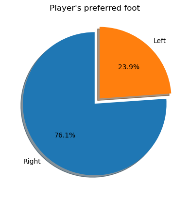

```python
# Count the values from the column
f21_pf = f21['Preferred Foot'].value_counts()
print(f21_pf)

# Creating the pie chart with the data
explode = [0.0, 0.1]
f21['Preferred Foot'].value_counts().plot(
    kind='pie',
    explode=explode,
    title="Player's preferred foot",
    autopct='%1.1f%%',
    shadow=True,
    startangle=90,
    ylabel="")
```

#### 5.3.2 How is the contract status?

Let's analyze the number of players under contract, on loan or free

```
Contract    17729
On Loan      1013
Free          237
Name: Contract Status, dtype: int64
```

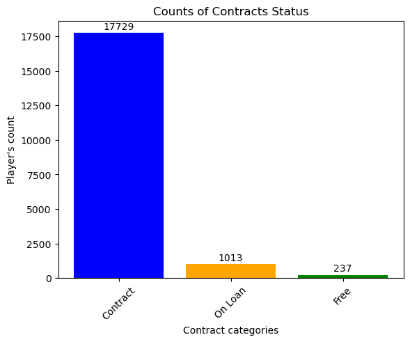

```python
# Count the values of the column
f21_cs = f21['Contract Status'].value_counts()
print(f21_cs)

# Creating the bar plot
bars = plt.bar(f21_cs.index, f21_cs.values, color=['blue', 'orange', 'green'])

# Adding total values at the top of each bar
for i, v in enumerate(f21_cs):
    plt.text(i, v + 100, str(v), ha='center', va='bottom', fontsize=10)

# Customize labels and title
plt.xlabel("Contract categories")
plt.ylabel("Player's count")
plt.title("Counts of Contracts Status")
plt.xticks(rotation=45)

plt.show()
```

#### 5.3.3 Clubs that pay more in salaries

Now we can also analyze the clubs that pay more in salaries to their player's

```
Club
No Club                         0
Llaneros de Guanare         10000
Central Coast Mariners      10350
Aragua FC                   10500
Waterford FC                10650
                           ...
Manchester United         2986000
Liverpool                 3028500
Manchester City           3639000
FC Barcelona              4083000
Real Madrid               4687000
Name: Wage, Length: 682, dtype: int32
```

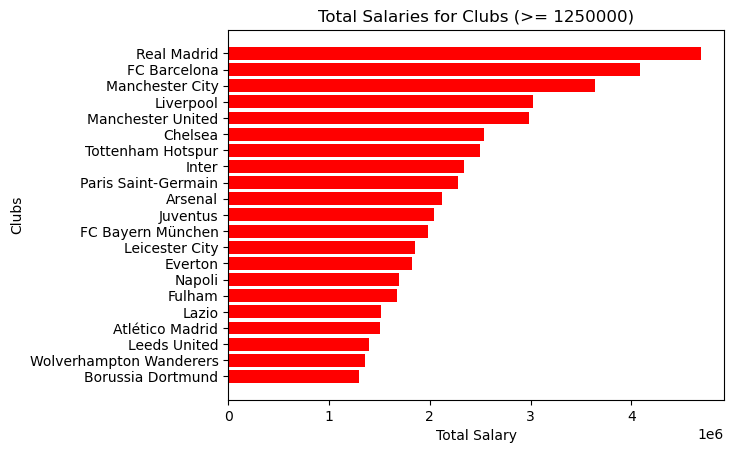

```python
# The data is group by clubs and sum their player's salaries
f21_csum = f21.groupby('Club')['Wage'].sum().sort_values()
print(f21_csum)

# Because there are a lot of clubs, I decided to apply a filter
ylab = f21_csum[f21_csum >= 1250000]

# Now let's create a barh chart to visualize our data
plt.barh(ylab.index, ylab.values, color="red")
plt.xlabel('Total Salary')
plt.ylabel('Clubs')
plt.title("Total Salaries for Clubs (>= 1250000)")

plt.show()
```

#### 5.3.4 Player's with the most 'Overall'

```python
f21_ov = f21[(f21['Overall'] >= 85)]

list_ov = f21_ov[['Name', 'Surname', 'Overall']].sort_values(by='Overall', ascending=False)
print(list_ov)
```

```
          Name                    Surname  Overall
0       Lionel                      Messi       93
1    Cristiano  Ronaldo dos Santos Aveiro       92
2          Jan                      Oblak       91
3        Kevin                  De Bruyne       91
4       Neymar        da Silva Santos Jr.       91
..         ...                        ...      ...
73     Clément                    Lenglet       85
74  Marquinhos                Aoás Corrêa       85
75       Riyad                     Mahrez       85
76     Ricardo            Barbosa Pereira       85
98       Marco                       Reus       85

[99 rows x 3 columns]
```

#### 5.3.5 Player's by Nationality

Now it's time to know the player's by their Nationality.

```python
f21_count = f21['Nationality'].value_counts()
f21_count
```

```
England                1705
Germany                1195
Spain                  1065
France                 1003
Argentina               943
                       ...
Malawi                    1
Rwanda                    1
São Tomé & Príncipe       1
Aruba                     1
Indonesia                 1
Name: Nationality, Length: 164, dtype: int64
```

Because there are too many countries with only one player, let's group them, and the condition will be, *countries with 100 players or fewer*</i>.

```python
# Let's see the list of countries with 100 players or fewer
f21_less_than_100 = f21_count[f21_count <= 100].index.tolist()
print(f21_less_than_100)
```

[output not shown]

```python
# Make a copy of the column
new_f21_count = f21['Nationality'].copy()
print(new_f21_count)
```

```
0        Argentina
1         Portugal
2         Slovenia
3          Belgium
4           Brazil
           ...
18974     China PR
18975      England
18976      England
18977     China PR
18978     China PR
Name: Nationality, Length: 18979, dtype: object
```

```python
# Replace the countries with 100 or fewer players
new_f21_count.loc[new_f21_count.isin(f21_less_than_100)] = 'Others'
print(new_f21_count)
```

```
0        Argentina
1         Portugal
2           Others
3          Belgium
4           Brazil
           ...
18974     China PR
18975      England
18976      England
18977     China PR
18978     China PR
Name: Nationality, Length: 18979, dtype: object
```

```python
# Count the new values
new_count = new_f21_count.value_counts(ascending=True)
new_count
```

```
Czech Republic          107
Ivory Coast             107
Ghana                   115
Wales                   127
Nigeria                 129
Serbia                  129
Senegal                 129
Croatia                 134
Bolivia                 148
Peru                    164
Chile                   189
Venezuela               199
Switzerland             211
Australia               238
Paraguay                239
Ecuador                 249
Scotland                285
Belgium                 295
Denmark                 300
Turkey                  317
Austria                 319
Romania                 321
Saudi Arabia            330
Colombia                339
Republic of Ireland     340
Korea Republic          340
Uruguay                 348
Poland                  354
Portugal                361
Norway                  362
Mexico                  362
China PR                364
United States           376
Sweden                  380
Italy                   387
Netherlands             438
Japan                   485
Brazil                  887
Argentina               943
France                 1003
Spain                  1065
Germany                1195
England                1705
Others                 2164
Name: Nationality, dtype: int64
```

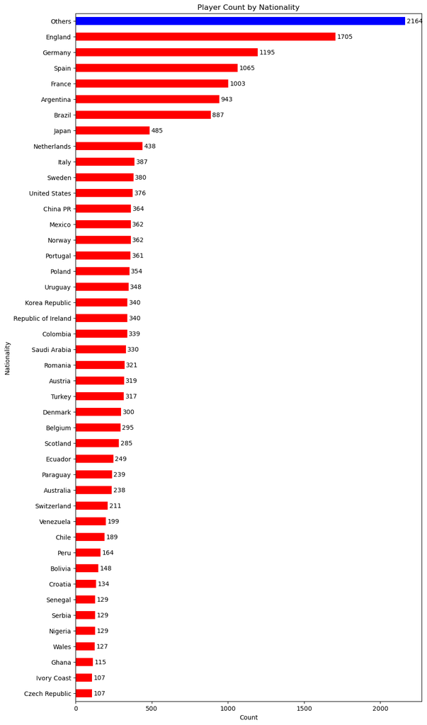

```python
# Creating our chart barh
colors = ['red' if index != 'Others' else 'blue' for index in new_count.index]
ax = new_count.plot(kind='barh', figsize=(10,20), color=colors)
plt.xlabel('Count')
plt.ylabel('Nationality')
plt.title('Player Count by Nationality')
for i, v in enumerate(new_count):
    ax.text(v +10, i, str(v), color='black', va='center')
```